# Cost-based variable selection for prediction models: the NBvarsel R package

- Show All Code
- Hide All Code

Authors

Affiliations

Lasai Barreñada

Department of Development and Regeneration, KU Leuven, Belgium

Leuven Unit for Health Technology Assessment Research (LUHTAR), KU Leuven, Belgium

Andrew Vickers

Department of Epidemiology and Biostatistics, Memorial Sloan Kettering Cancer Center, New York, NY, USA

Laure Wynants

Department of Development and Regeneration, KU Leuven, Belgium

Leuven Unit for Health Technology Assessment Research (LUHTAR), KU Leuven, Belgium

Department of Epidemiology, CAPHRI Care and Public Health Research Institute, Maastricht University, Maastricht, Netherlands

Bieke Tack

Department General Internal Medicine, University Hospitals Leuven, Leuven, Belgium

Dirk Timmerman

Department of Development and Regeneration, KU Leuven, Belgium

Department Obstetrics & Gynecology, University Hospitals Leuven, Leuven, Belgium

Ewout W. Steyerberg

Julius Centre for Health Sciences and Primary Care, University Medical Centre Utrecht, Utrecht, Netherlands

Ben Van Calster

Department of Development and Regeneration, KU Leuven, Belgium

Leuven Unit for Health Technology Assessment Research (LUHTAR), KU Leuven, Belgium

Julius Centre for Health Sciences and Primary Care, University Medical Centre Utrecht, Utrecht, Netherlands

[figure not shown]

**NoteNote on Figure and Table Numbering**

In this computational report, each figure and table heading begins with an automatically generated sequential number denoting its order within this document (e.g., **Figure 1**, **Figure 2**, **Table 1**, **Table 2**). The second identifier within the title or caption (e.g., **Figure 1A**, **Figure S1**, **Table 2**, **Table S4**) corresponds to its respective label in the main manuscript and supplementary materials.

## Overview of Supplementary & Online Only Materials

**Supplementary Figures**

| Manuscript Identifier | Report Description | Study / Context | Link |
| --- | --- | --- | --- |
| **Figure S1** | Permutation variable importance across top 10% models | Ovarian Cancer (IOTA) | View Figure |
| **Figure S2** | Clustered calibration plot (2MA-C method) | Ovarian Cancer (IOTA) | View Figure |
| **Figure S3** | All-subset model performance plot (unadjusted Net Benefit) | Ovarian Cancer (IOTA) | View Figure |
| **Figure S4** | All-subset model performance plot (harm-adjusted Net Benefit) | Ovarian Cancer (IOTA) | View Figure |
| **Figure S5 (left)** | Net benefit variable importance (BE NBvarsel 1) | MIMIC-IV ED | View Figure |
| **Figure S5 (right)** | Net benefit variable importance (BE NBvarsel 2) | MIMIC-IV ED | View Figure |
| **Figure S6** | Test-set calibration curves across comparison models | MIMIC-IV ED | View Figure |
| **Figure S7** | Net benefit permutation variable importance bar chart | Salmonella (DENTS) | View Figure |
| **Figure S8** | All-subset model performance plot | Salmonella (DENTS) | View Figure |
| **Figure S9** | Predicted risk distributions by outcome (NBvarsel vs Published) | Salmonella (DENTS) | View Figure |
| **Figure S10** | Apparent calibration curves | Salmonella (DENTS) | View Figure |
| **Figure S11** | Apparent decision curve analysis | Salmonella (DENTS) | View Figure |
| **Figure S12** | Predictor retention frequencies across 1,000 bootstrap iterations | Salmonella (DENTS) | View Figure |

**Online Only Figures**

| Report Identifier | Description | Study / Context | Link |
| --- | --- | --- | --- |
| **Online Only Figure 1** | Net benefit-based variable importance for the simple illustration | Motivating Example | View Figure |
| **Online Only Figure 2** | Predicted risk distributions by malignancy status | Ovarian Cancer (IOTA) | View Figure |
| **Online Only Figure 3** | Scatter plots comparing BE NBvarsel vs full model predicted risks | MIMIC-IV ED | View Figure |
| **Online Only Figure 4** | Histograms of predicted probabilities by hospitalization status | MIMIC-IV ED | View Figure |
| **Online Only Figure 5** | Decision curve analysis comparing net benefit across comparison models | MIMIC-IV ED | View Figure |
| **Online Only Figure 6** | Histograms of estimated risk distributions by NTS infection status | Salmonella (DENTS) | View Figure |
| **Online Only Figure 7** | Optimism-corrected decision curve analysis across 0%–100% thresholds | Salmonella (DENTS) | View Figure |

**Supplementary & Online Only Tables**

| Identifier | Description | Study / Context | Link |
| --- | --- | --- | --- |
| **Table S1** | Predictor and outcome distributions by training/test set | Ovarian Cancer (IOTA) | View Table |
| **Table S2** | Predictor and outcome distributions by training/test set | MIMIC-IV ED | View Table |
| **Table S3** | Descriptive baseline statistics | Salmonella (DENTS) | View Table |
| **Table S4** | Bootstrap discrimination, calibration, and Brier metrics | Salmonella (DENTS) | View Table |
| **Online Only Table 1** | Minimum sample size calculation (Riley criteria) | Ovarian Cancer (IOTA) | View Table |
| **Online Only Table 2** | Best model statistics from exhaustive search | Ovarian Cancer (IOTA) | View Table |
| **Online Only Table 3** | Full performance table of all evaluated subset models | Ovarian Cancer (IOTA) | View Table |
| **Online Only Table 4** | Decision-threshold adjusted net benefit table | Ovarian Cancer (IOTA) | View Table |
| **Online Only Table 5** | Minimum sample size calculation (Riley criteria) | MIMIC-IV ED | View Table |
| **Online Only Table 6** | Detailed discrimination and calibration performance metrics | MIMIC-IV ED | View Table |
| **Online Only Table 7** | Minimum sample size calculation (Riley criteria) | Salmonella (DENTS) | View Table |
| **Online Only Table 8** | Predictor retention percentages across bootstrap iterations | Salmonella (DENTS) | View Table |
| **Online Only Table 9** | Optimism-corrected median net benefit across 20%–50% thresholds | Salmonella (DENTS) | View Table |

**NoteSession info**

**The analysis was performed on an HP EliteDesk 8 Tower G11 Desktop AI PC equipped with an Intel Core Ultra 9 285 processor (24 cores, base frequency 2.50 GHz) and 128 GB of RAM, running on a 64-bit Windows operating system and with R version 4.4. The parallelized processes used 23 cores.**

## 0.1 Installation

**Installation of the NB_varsel package**

```r
require(pak)
# Install dev version
pak::pkg_install("LasaiBarrenada/NB_varsel@v0.1.2")
```

## 0.2 Setup

**Loading required packages**

```r
library(NBvarsel)
library(ggplot2)
library(stringr)
library(ggpubr)
library(dplyr)
library(rms)
library(utils)
library(pROC)
library(patchwork)
library(tidyr)
library(readr)
library(glmnet)
library(gt)
library(gtsummary)
library(ggsci)
library(dcurves)
library(CalibrationCurves)
library(predictionDatasets)
library(flextable)
library(pmsampsize)
```

**Defining color palette for the figures**

```r
global_model_colors <- c(
  "Treat all" = pal_bmj()(9)[8],
  "Treat All" = pal_bmj()(9)[8],
  "Treat none" = pal_bmj()(9)[6],
  "Treat None" = pal_bmj()(9)[6],
  "NBvarsel" = pal_bmj()(9)[1],
  "NBvarsel (Adj. NB)" = pal_bmj()(9)[2],


  # Simple Illustration / General
  "Full" = "black",
  "BE" = pal_bmj()(9)[5],
  "Full model" = "black",


  # Ovarian Cancer (IOTA)
  "ADNEX with CA125" = pal_bmj()(9)[3],
  "ADNEX without CA125" = pal_bmj()(9)[4],
  "LASSO" = pal_bmj()(9)[7],

  # MIMIC
  "BE NBvarsel 1" = pal_bmj()(9)[1],
  "BE NBvarsel 1 (50-70%)" = pal_bmj(alpha = 0.8)(9)[1],

  "BE NBvarsel 2" = pal_bmj()(9)[2],
  "BE NBvarsel 2 (50-70%)" = pal_bmj(alpha = 0.8)(9)[2],

  "Baseline" = pal_bmj()(9)[4],


  "Published model" = pal_bmj()(9)[2],
  "Published" = pal_bmj()(9)[2]
)
```

# 1 What is this?

This document is a static companion to our publication. Rather than discussing the findings in depth, this site is designed to make the results easier to navigate. It includes:

- Brief introductions to the presented results.
- Fully reproducible code.
- Interactive figures for better comparison.

A full discussion of the findings can be found in the main paper. For the latest updates to the `NBvarsel` package, please refer to the documentation and vignettes on the [package’s website](https://lasaibarrenada.github.io/NB_varsel/).

# 2 Introduced functions

| Function | Description |
| --- | --- |
| `nb_varsel()` | Variable selection via cross-validated Net Benefit |
| `all_subset_plot()` | Two-panel model comparison visualisation |
| `VIF_plot()` | Permutation importance bar chart |

# 3 Motivating example

**TipReproducible section**

This section is reproducible because the data-generation process is included in the code.

**Motivating example data generation and model building**

```r
set.seed(123)
n <- 10000


X_img   <- rnorm(n, mean = 0, sd = 1)
X_blood <- rnorm(n, mean = 0, sd = 1)
X_clin  <- rnorm(n, mean = 0, sd = 1)

# Imaging is strong (0.8), Blood is moderate (0.5), Clinical is weak (0.4)
log_odds <- -1.5 + (0.8* X_img) + (0.5 * X_blood) + (0.4 * X_clin)

prob <- plogis(log_odds)
Y <- rbinom(n, size = 1, prob = prob)


df <- data.frame(X_img = X_img, X_blood = X_blood, X_clin = X_clin, Y = Y)

# Define harms of each predictor
harms <- c(0.05, 0.01, 0)
names(harms) <- c("X_img", "X_blood", "X_clin")
library(rms)
# Fit logistic regression model
model <- lrm(Y ~ ., data = df)
modelbw <- fastbw(model)

exhaustive <- nb_varsel(
  data = df ,
  outcome_var = "Y", include_interactions = F,
  costs = harms,
  cv_folds = 5,
  mode = "exhaustive",
  thresholds = seq(0.15, 0.40, by = 0.01),
  allow_parallel =F,
  permutation = T,
  splines = F,
  n_knots = 3,
  verbose = F

)
```

**Decision curve analysis for the simple illustration**

```r
train_full <- lrm(Y ~ ., data = df)
train_nbar <- lrm(Y ~ X_blood + X_clin, data = df)
df$pred_full <- predict(train_full, type = "fitted")
df$pred_nbar <- predict(train_nbar, type = "fitted")

dca_plot <- dca(
  Y ~ pred_full  + pred_nbar,
 data = df,
 thresholds = seq(0.01, 0.50, by = 0.01),
  label = list(
    pred_nbar     = "NBvarsel",
    pred_full = "Full model"

  )
)
dca_data <- dca_plot$dca
dca_data <- dca_data |> mutate(cost =case_when(label == "NBvarsel" ~ 0.01,
                             label == "Full model" ~ 0.06,
                             label =="Treat All" ~ 0,
                             label == "Treat None" ~ 0 )) |> mutate(`Adjusted Net Benefit` = net_benefit - cost)

dca <- ggplot(dca_data , aes(x = threshold , y = net_benefit, color = label, group = label)) +
  geom_line(lwd = 0.7) +
  theme_classic(base_size = 12) +
  labs(x = "Decision Threshold", y = "Net Benefit") +
  scale_color_manual(values = global_model_colors,aesthetics = c("fill", "color"), name = "Strategy") +
  theme(legend.text = element_text(size = 9),
        legend.title = element_text(size = 9),
        legend.key.size = unit(0.3, "cm"),
        legend.margin = margin(t = 0, r = 0, b = 0, l = 0, unit = "pt"),
        legend.box.margin = margin(t = 0, r = 0, b = 0, l = 0, unit = "pt"))+ coord_cartesian(xlim = c(0, 0.50), y = c(-0.01, 0.20))

dca_adj <- ggplot(dca_data , aes(x = threshold , y = `Adjusted Net Benefit`, color = label, group = label)) +
  geom_line(lwd = 0.7) +
  theme_classic(base_size = 12) +
  labs(x = "Decision Threshold", y = "Adjusted Net Benefit") +
  scale_color_manual(values = global_model_colors,aesthetics = c("fill", "color"), name = "Model") +
  theme(legend.text = element_text(size = 10))+ coord_cartesian(xlim = c(0, 0.5), y = c(-0.01, 0.20))

ggsave(dca_adj, filename = file.path(path_figures_paper, "Figure_1A.pdf"), width = 12/2, height = 6, dpi = 300)
Fig_dca <- ggarrange(dca , dca_adj, ncol = 2, nrow = 1, labels = c("A", "B"), common.legend = TRUE, legend = "bottom" )
```

As a motivating example, we simulated a dataset ($N = 10,000$) to evaluate a biopsy risk prediction model incorporating three continuous predictors. The true data-generating model is defined as $\text{logit}(P(Y = 1)) = -1.5 + 0.8X_{\text{img}} + 0.5X_{\text{blood}} + 0.4X_{\text{clin}}$. In this scenario, $X_{\text{img}}$ represents a strongly predictive but highly burdensome imaging test (test harm = 0.05), $X_{\text{blood}}$ is a moderate blood biomarker (test harm = 0.01), and $X_{\text{clin}}$ is a weakly predictive, cost-free clinical variable. Standard variable selection based on statistical performance (e.g., backward elimination using Wald’s statistic) favors retaining all predictors to maximize model discrimination. However, when evaluating clinical utility across decision thresholds of 15% to 40%, the full model’s utility is heavily penalized by the high cost of imaging (Table 1). Conversely, our proposed exhaustive net benefit (NB)-guided selection explicitly incorporates these clinical harms. By optimizing for cost-adjusted NB, the algorithm excludes the imaging predictor, identifying an optimal, simpler model containing only $X_{\text{blood}}$ and $X_{\text{clin}}$ (total test harm = 0.01). Cost-adjusted decision curves confirm that despite a reduction in purely statistical discrimination, this simpler model achieves superior clinical utility. This example clearly illustrates that the best statistical subset of predictors does not necessarily translate to the best cost-utility for clinical decision-making (Figure 2).

**Variable importance for the simple illustration**

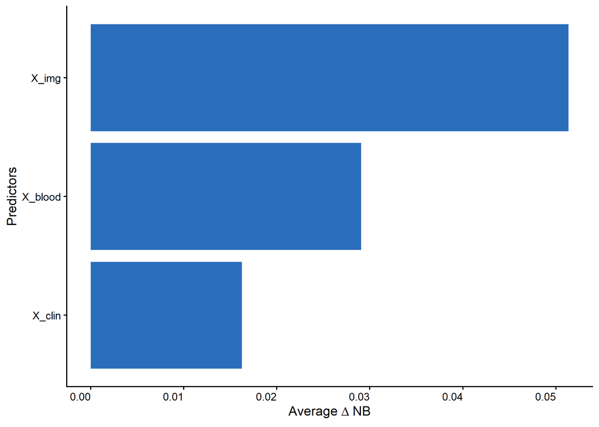

Figure 1: Online Only Figure 1. Net benefit based variable importance for the simple illustration. NB: Net benefit.

```r
data_dict_me <-  data.frame(
  variable = c("X_img", "X_blood", "X_clin"),
  description = c("Imaging test (strong predictor, high cost)", "Blood biomarker (moderate predictor, moderate cost)", "Clinical variable (weak predictor, no cost)")
)

tbl_train <- exhaustive$all_models
vif_simple <- VIF_plot(tbl_train)$plot + theme(axis.text.x = element_text(angle = 0, hjust = 1))
vif_simple
all_subset_simple <- all_subset_plot(tbl_train,filter = 100,metric = "Avg_Adj_Net_Benefit", y_axis = "Adjusted Net Benefit")
# all_subset_simple

Fig1_vif <- ggarrange(vif_simple, all_subset_simple, ncol = 2, nrow = 1, labels = c("A", "B"))
ggsave(vif_simple, filename = file.path(path_figures_paper, "Online_Only_Figure_1.svg"), width = 12/2, height = 6, dpi = 300)
ggsave(vif_simple, filename = file.path(path_figures_paper, "Online_Only_Figure_1.pdf"), width = 12/2, height = 6, dpi = 300)
ggsave(all_subset_simple, filename = file.path(path_figures_paper, "Figure_1B.svg"), width = 12/2, height = 6, dpi = 300)
ggsave(all_subset_simple, filename = file.path(path_figures_paper, "Figure_1B.pdf"), width = 12/2, height = 6, dpi = 300)
```

**Variable importance and all-subset plot for the simple illustration**

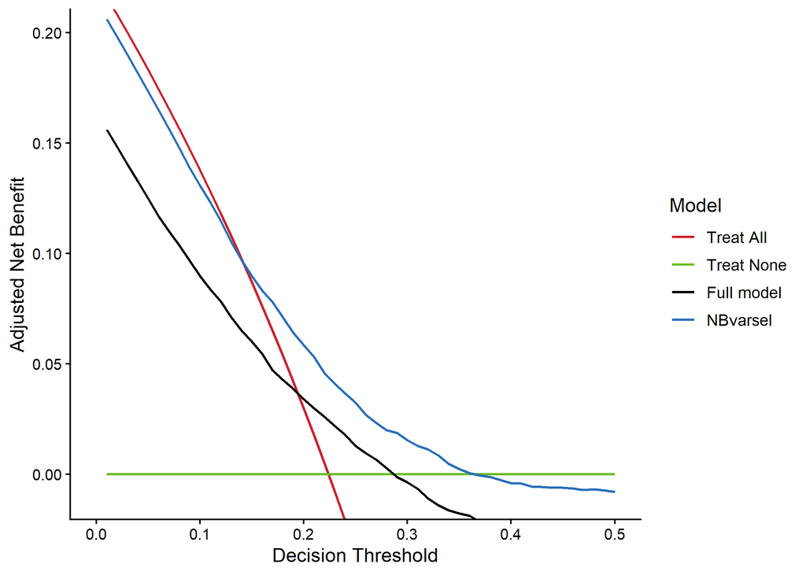

Figure 2: Figure 1A. Cost adjusted decision curve analysis for the motivating example for NBvarsel model (blue), full model (black), treat all (red) and treat none (green).

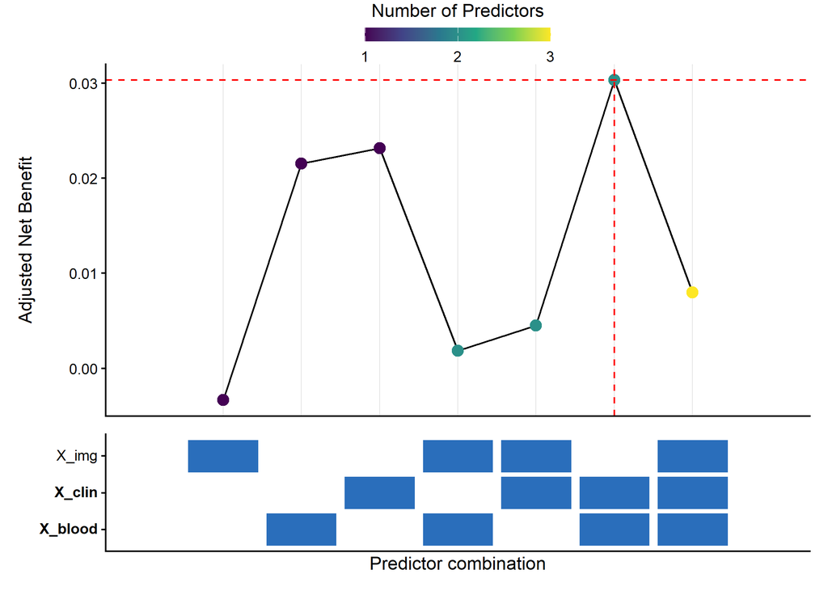

Figure 3: Figure 1B. All subset plot for the simple illustration. Predictors in bold optimize net benefit.

```r
Fig1 <- ggarrange(dca_adj + theme(legend.position = "None"), all_subset_simple, ncol = 2, nrow = 1, labels = c("A", "B"))

ggsave(Fig1, filename = file.path(path_figures_paper, "Figure_1.svg"), width = 12, height = 6, dpi = 300)
ggsave(Fig1, filename = file.path(path_figures_paper, "Figure_1.pdf"), width = 12, height = 6, dpi = 300)
dca_adj
all_subset_simple
```

**Best subset table for the simple illustration**

```r
simple_train <- tbl_train |>
  select(Model, Total_Cost, Avg_Net_Benefit, Avg_Adj_Net_Benefit, AUC, Brier) |> arrange(-Avg_Adj_Net_Benefit)  |> gt(id = "tb-train")  |>
  fmt_number(
    columns = c("AUC", "Brier", "Avg_Adj_Net_Benefit", "Avg_Net_Benefit", "Total_Cost"),
    decimals = 6
  ) |>
  cols_label(
    Model = "Included predictors",
    AUC = "AUC",
    Brier = "Brier Score",
    Avg_Net_Benefit = "Avg. Net Benefit",
    Total_Cost = "Total Cost",
    Avg_Adj_Net_Benefit = "Avg. Adj. Net Benefit",
  )


simple_train
```

Table 1: Table 1. Results for the motivating example. Xclin: clinical predictor, Ximg: imaging predictor, Xblood: blood biomarker. Sorted by average adjusted net benefit.

| Included predictors | Total Cost | Avg. Net Benefit | Avg. Adj. Net Benefit | AUC | Brier Score |
| --- | --- | --- | --- | --- | --- |
| X_blood, X_clin | 0.010000 | 0.040297 | 0.030297 | 0.669017 | 0.162685 |
| X_clin | 0.000000 | 0.023164 | 0.023164 | 0.600359 | 0.170146 |
| X_blood | 0.010000 | 0.031515 | 0.021515 | 0.638132 | 0.166590 |
| X_img, X_blood, X_clin | 0.060000 | 0.067989 | 0.007989 | 0.754671 | 0.147707 |
| X_img, X_clin | 0.050000 | 0.054519 | 0.004519 | 0.714418 | 0.155900 |
| X_img, X_blood | 0.060000 | 0.061838 | 0.001838 | 0.735281 | 0.151690 |
| X_img | 0.050000 | 0.046665 | −0.003335 | 0.690021 | 0.159453 |

# 4 Ovarian cancer - IOTA

**ImportantNot reproducible section**

This section cannot be reproduced because the original data are not publicly available. The code is included here for transparency.

The optimal management of patients with an ovarian tumour depends on the histology of the mass. In 2014, the [ADNEX model](https://pubmed.ncbi.nlm.nih.gov/25320247/) was published using data from IOTA phases 1-3 ($N = 5909$, 1929 events). We use the IOTA phase 5 study ($N = 6847$, 1713 events) as a validation dataset; it was prospectively collected for the external validation of ADNEX. The variable selection procedure is detailed in the supplementary material of the original publication; we refer the reader there for details. The original ADNEX model used nine predictors: three clinical predictors (age, serum CA125, and centre type) and six ultrasound-based predictors (lesion diameter, solid tissue proportion, >10 cyst locules, number of papillary projections, acoustic shadows, and ascites). Although family history was initially considered, it was excluded during the variable selection process. For our analysis, missing CA125 values were handled using regression-based imputation based on all other ADNEX predictors, following recent methodological recommendations.  
We extended the original predictor set with six additional features: bilateral masses (yes/no), irregular internal cyst walls (yes/no), Doppler colour score (four levels), maximum solid-component diameter, presence of papillary projections (yes/no), and lesion-associated pain (yes/no). The distribution of predictors by outcome in the training and test datasets is shown in Table 2. In total, 65,536 predictor combinations were evaluated across decision thresholds corresponding to risks from 1% to 20%, using 20-fold cross-validation. The average net benefit across these thresholds was the metric optimized. We then assessed discrimination using the AUC, the observed-to-expected (O:E) ratio, clustered calibration, and decision-curve analysis. Adjusted NB was also calculated using harms based on three groups of variables: clinical-history variables (no cost and assumed to be available for all patients from the records), ultrasound-based variables (Test harm = 1/200), and blood-based variables (Test harm = 1/80). We compared NB-based variable selection with LASSO and backward elimination.

## 4.1 Dataset descriptives

**Create descriptive statistics for the ovarian cancer training and test datasets**

```r
vars <- c("malignant",
          "age",
          "ca125",
          "family_history",
          "locules_gt_10",
          "oncology_center",
          "max_diam_lesion",
          "papillary_count",
          "acoustic_shadows",
          "ascites",
          "ireg_walls",
          "bilateral",
          "color_score",
          "pain",
          "max_diam_solid",
          # "center",
          "papillary_presence",
          "prop_solid"
)
data_dict_adnex <- c(
  "malignant"          = "Malignancy Status",
  "age"                = "Age",
  "ca125"              = "CA125",
  "family_history"     = "Family history of OC",
  "locules_gt_10"      = ">10 Locules",
  "oncology_center"    = "Oncology Center",
  "max_diam_lesion"    = "Max. diam. lesion",
  "papillary_count"    = "N. papillations",
  "acoustic_shadows"   = "Acoustic shadows",
  "ascites"            = "Ascites",
  "ireg_walls"         = "Irregular walls",
  "bilateral"          = "Bilateral",
  "color_score"        = "Colour score",
  "pain"               = "Pain",
  "max_diam_solid"     = "Max. diam. solid part",
  "papillary_presence" = "Presence of papillations",
  "prop_solid"         = "Proportion of solid tissue" # Retained from earlier
)

# final_df is a data frame that contains the combined training and test datasets with the relevant variables for the ADNEX model.
rename_dict_adnex <- stats::setNames(names(data_dict_adnex), data_dict_adnex)



tbl_data_adnex <- final_df %>% select(vars,train) #|> rename(all_of(rename_dict_adnex))
tbl_data_adnex$train <- factor(tbl_data_adnex$train,levels = c("training","test"), labels = c("Training", "Test"))

tbl_data_adnex$malignant <- factor(tbl_data_adnex$malignant, levels = c(0,1), labels = c("Benign", "Malignant"))


smry_adnex_tbl <- tbl_data_adnex |> rename(all_of(rename_dict_adnex)) |> tbl_strata(strata = train,
    ~.x |>  tbl_summary(by = `Malignancy Status`, missing_text = "Missing",  statistic = list(all_continuous() ~
  "{median} ({p25}, {p75})[{min}-{max}]", all_categorical() ~ "{n} ({p}%)"), missing_stat = "{N_miss} ({p_miss}%)")) |>  modify_header(
    all_stat_cols() ~ "**{level}**\nN = {n} ({style_number(p * 100, digits = 0)}%)"
  )

smry_adnex_tbl
smry_adnex_tbl |> modify_caption("Table S1. Predictor and outcome distribution of the ovarian cancer case study by training/test.") |> as_flex_table() |> save_as_docx(path = file.path(path_tables_paper, "Table_S1.docx"))
```

Table 2: Table S1. Predictor and outcome distribution of the ovarian cancer case study by training/test.

| **Characteristic** | **Training** **Benign** N = 3980 (67%)<sup>1</sup> | **Training** **Malignant** N = 1929 (33%)<sup>1</sup> | **Test** **Benign** N = 5134 (75%)<sup>1</sup> | **Test** **Malignant** N = 1713 (25%)<sup>1</sup> |
| --- | --- | --- | --- | --- |
| Age | 42 (32, 54)[8-96] | 57 (46, 66)[14-94] | 47 (35, 61)[18-99] | 57 (46, 67)[18-92] |
| CA125 | 18 (11, 39)[1-40,140] | 181 (37, 647)[2-38,161] | 16 (9, 33)[1-36,620] | 133 (34, 538)[3-78,200] |
| Missing | 1,447 (36%) | 358 (19%) | 2,998 (58%) | 228 (13%) |
| Family history of OC | 79 (2.0%) | 85 (4.4%) | 158 (3.1%) | 76 (4.4%) |
| >10 Locules | 199 (5.0%) | 272 (14%) | 307 (6.0%) | 327 (19%) |
| Oncology Center | 2,178 (55%) | 1,571 (81%) | 2,926 (57%) | 1,449 (85%) |
| Max. diam. lesion | 63 (45, 87)[8-550] | 89 (58, 133)[8-430] | 51 (36, 73)[7-751] | 86 (56, 125)[10-510] |
| N. papillations |  |  |  |  |
| 0 | 3,424 (86%) | 1,347 (70%) | 4,623 (90%) | 1,244 (73%) |
| 1 | 333 (8.4%) | 162 (8.4%) | 310 (6.0%) | 154 (9.0%) |
| 2 | 80 (2.0%) | 68 (3.5%) | 87 (1.7%) | 56 (3.3%) |
| 3 | 66 (1.7%) | 71 (3.7%) | 47 (0.9%) | 48 (2.8%) |
| 4 | 77 (1.9%) | 281 (15%) | 67 (1.3%) | 211 (12%) |
| Acoustic shadows | 676 (17%) | 66 (3.4%) | 1,179 (23%) | 125 (7.3%) |
| Ascites | 64 (1.6%) | 656 (34%) | 54 (1.1%) | 436 (25%) |
| Irregular walls | 1,130 (28%) | 1,245 (65%) | 1,171 (23%) | 1,078 (63%) |
| Bilateral | 540 (14%) | 601 (31%) | 718 (14%) | 567 (33%) |
| Colour score |  |  |  |  |
| 1 | 1,565 (39%) | 70 (3.6%) | 2,781 (54%) | 56 (3.3%) |
| 2 | 1,493 (38%) | 411 (21%) | 1,483 (29%) | 280 (16%) |
| 3 | 788 (20%) | 849 (44%) | 754 (15%) | 783 (46%) |
| 4 | 134 (3.4%) | 599 (31%) | 116 (2.3%) | 594 (35%) |
| Pain | 835 (21%) | 257 (13%) | 792 (15%) | 196 (11%) |
| Max. diam. solid part | 0 (0, 12)[0-50] | 50 (30, 50)[0-50] | 0 (0, 0)[0-751] | 49 (26, 75)[0-250] |
| Presence of papillations | 556 (14%) | 582 (30%) | 511 (10.0%) | 469 (27%) |
| Proportion of solid tissue | 0.00 (0.00, 0.20)[0.00-1.00] | 0.45 (0.30, 0.69)[0.00-1.00] | 0.00 (0.00, 0.00)[0.00-1.00] | 0.65 (0.37, 1.00)[0.00-1.00] |

<sup>1</sup> Median (Q1, Q3)[Min-Max]; n (%)

**Impute missing CA125 values and prepare ADNEX analysis datasets**

```r
# Regression imputation CA125 ------------------------------------------------------

model_imputation <- lm(log(ca125, base = 2) ~ oncology_center + age   + max_diam_lesion + ascites +papillary_count + prop_solid + acoustic_shadows + locules_gt_10, data = final_df %>% filter(dataset_varsel == "training"))
final_df$log_ca125_imputed <- predict(model_imputation, newdata = final_df)
final_df$ca125_imputed <- 2^(final_df$log_ca125_imputed)
final_df$ca125 <- ifelse(is.na(final_df$ca125), final_df$ca125_imputed, final_df$ca125)


final_df <- ADNEX(Age = age,Oncocenter = oncology_center,lesdmax = max_diam_lesion,soldmaxorig = max_diam_solid,loc10 = locules_gt_10,Papnr = papillary_count,Shadows = acoustic_shadows,Ascites = ascites,ca125 = ca125,wica = T,data = final_df,UseRcpp = F)



# Variable selection ------------------------------------------------------
set.seed(1234)

all_missing <- final_df %>%
  group_by(dataset_varsel) %>%
  summarise(across(everything(), ~sum(is.na(.))))

final_df_vars <- final_df %>% select(-locules_raw, -log_ca125_imputed, -ca125_imputed,
                                     -set, -phase, -benign_descriptors,- family_history_BRCA,
                                     - personal_history_BRCA, -outcome5)

training_data_oc <- final_df_vars %>% filter(dataset_varsel == "training")
test_data_oc <- final_df_vars %>% filter(dataset_varsel == "validation")
```

**Define predictor groups, measurement costs, and net-benefit selection settings**

```r
vars_adnex <- c("malignant",
          "age",
          "ca125",
          "family_history",
          "locules_gt_10",
          "oncology_center",
          "max_diam_lesion",
          "papillary_count",
          "acoustic_shadows",
          "ascites",
          "ireg_walls",
          "bilateral",
          "color_score",
          "pain",
          "max_diam_solid",
          # "center",
          "papillary_presence",
          "prop_solid"
)
grouped_costs <- list(
  # Group 1: Clinical History (Cheap)
  history = list(cost = 0, vars = c("age","family_history","oncology_center","pain")),

  # Group 2: US (Test harm = 1/200 = 0.005)
  ## TT 200
  US = list(cost = 1/200,
            vars = c("max_diam_lesion",  "prop_solid",
                     "locules_gt_10", "papillary_count" ,
                     "acoustic_shadows", "ascites", "bilateral",
                     "ireg_walls","papillary_presence", "color_score", "max_diam_solid")),
  # Group 3: Blood (Test harm = 1/80 = 0.0125)
  blood = list(cost = 1/80, vars = c("ca125"))
  ## TT 80
)
```

## 4.2 Minimum sample size analysis

**Calculate the required sample size for the ovarian cancer case study**

```r
labs_full <- NBvarsel:::get_term_labels(vars_adnex[-1], data = training_data_oc, n_knots = 3)
fmla_full <- reformulate(termlabels = labs_full, response = "malignant")
model_full <- lrm(fmla_full, data = training_data_oc)


sample_size <- pmsampsize(type = "b", parameters = length(model_full$coefficients), prevalence = 0.25, cstat = 0.93, shrinkage = 0.9,  seed = 1)

sample_size$results_table |>
  as.data.frame() |>
  gt(rownames_to_stub = TRUE) |>
  tab_stubhead(label = "Criteria") |>
  tab_header(title = "Sample Size Calculation for the ovarian cancer case study")
```

Table 3: Online Only Table 1. Minimum sample size calculation for the ovarian cancer case study.

Sample Size Calculation for the ovarian cancer case study

| Criteria | Samp_size | Shrinkage | Parameter | CS_Rsq | Max_Rsq | Nag_Rsq | EPP |
| --- | --- | --- | --- | --- | --- | --- | --- |
| Criteria 1 | 338 | 0.900 | 22 | 0.4307 | 0.675 | 0.638 | 3.84 |
| Criteria 2 | 485 | 0.927 | 22 | 0.4307 | 0.675 | 0.638 | 5.51 |
| Criteria 3 | 289 | 0.927 | 22 | 0.4307 | 0.675 | 0.638 | 3.28 |
| Final | 485 | 0.927 | 22 | 0.4307 | 0.675 | 0.638 | 5.51 |

## 4.3 Exhaustive net benefit variable selection

**Run exhaustive net-benefit variable selection for the ovarian cancer case study**

```r
start_time <- Sys.time()
exhaustive_results <- nb_varsel(
  data = training_data_oc %>% select(vars_adnex),
  outcome_var = "malignant",
  costs = grouped_costs,
  thresholds =seq(0.01,0.2, by = 0.01),
  include_interactions = F,
  cv_folds = 20,
  mode = "exhaustive",
  allow_parallel = T,
  permutation = TRUE,
  splines = T,
)
end_time <- Sys.time()
run_duration <- end_time - start_time
```

Table 4: Online Only Table 2. Best model statistics from the exhaustive search for the ovarian cancer case study.

| Included predictors | AUC | Brier Score | Total Cost | Avg. Adj. Net Benefit | Avg. Net Benefit |
| --- | --- | --- | --- | --- | --- |
| age, locules_gt_10, oncology_center, max_diam_lesion, papillary_count, acoustic_shadows, ascites, ireg_walls, bilateral, color_score, pain, papillary_presence, prop_solid | 0.952 | 0.081 | 0.005 | 0.290 | 0.295 |

Table 4 shows the performance of the best cost-adjusted model identified in the exhaustive search. The model has an AUC of 0.952, a Brier score of 0.081, an average net benefit of 0.295, and an average adjusted net benefit of 0.29.

**Rank exhaustive-search models by raw and adjusted net benefit**

```r
exhaustive_results$all_models$Rank_NB <- rank(-exhaustive_results$all_models$Avg_Net_Benefit, ties.method = "min")
exhaustive_results$all_models$Rank_adj_NB <- rank(-exhaustive_results$all_models$Avg_Adj_Net_Benefit, ties.method = "min")
tbl_data <- exhaustive_results$all_models |>
  select(Rank_NB, Rank_adj_NB, Model, AUC, Brier, Total_Cost, Avg_Adj_Net_Benefit, Avg_Net_Benefit)

if (!knitr::is_html_output()) {
  tbl_data <- tbl_data |> slice_head(n = 20)
}

tbl <- tbl_data |> gt(id = "tab2") |>
  fmt_number(
    columns = c("AUC", "Brier", "Total_Cost", "Avg_Adj_Net_Benefit", "Avg_Net_Benefit"),
    decimals = 3
  ) |>
  cols_label(
    Rank_NB = "Rank based on NB",
    Rank_adj_NB = "Rank based on adjusted NB",
    Model = "Included predictors",
    AUC = "AUC",
    Brier = "Brier Score",
    Avg_Net_Benefit = "Avg. Net Benefit",
    Total_Cost = "Total Cost",
    Avg_Adj_Net_Benefit = "Avg. Adj. Net Benefit",
  )

if (knitr::is_html_output()) {
  tbl <- tbl |> opt_interactive(
    use_pagination = TRUE,
    page_size_default = 10,
    use_filters = TRUE,
    use_compact_mode = TRUE
  )
}
tbl
```

Table 5: Online Only Table 3. Performance of all models evaluated in the exhaustive search for the ovarian cancer case study.

| Rank based on NB | Rank based on adjusted NB | Included predictors | AUC | Brier Score | Total Cost | Avg. Adj. Net Benefit | Avg. Net Benefit |
| --- | --- | --- | --- | --- | --- | --- | --- |
| 37 | 1 | age, locules_gt_10, oncology_center, max_diam_lesion, papillary_count, acoustic_shadows, ascites, ireg_walls, bilateral, color_score, pain, papillary_presence, prop_solid | 0.951553870922595 | 0.080568661923747 | 0.005 | 0.290248659780001 | 0.295248659780001 |
| 38 | 2 | age, family_history, locules_gt_10, oncology_center, max_diam_lesion, papillary_count, acoustic_shadows, ascites, ireg_walls, bilateral, color_score, pain, papillary_presence, prop_solid | 0.951552605516739 | 0.0806180286038073 | 0.005 | 0.290221163257672 | 0.295221163257672 |
| 39 | 3 | age, locules_gt_10, oncology_center, max_diam_lesion, papillary_count, acoustic_shadows, ascites, ireg_walls, bilateral, color_score, pain, max_diam_solid, prop_solid | 0.951695865171419 | 0.080423160694461 | 0.005 | 0.290210175483636 | 0.295210175483636 |
| 43 | 4 | age, family_history, locules_gt_10, oncology_center, max_diam_lesion, papillary_count, acoustic_shadows, ascites, ireg_walls, bilateral, color_score, pain, max_diam_solid, prop_solid | 0.951684242002007 | 0.0804767306184678 | 0.005 | 0.290204933488546 | 0.295204933488546 |
| 52 | 5 | age, locules_gt_10, oncology_center, max_diam_lesion, papillary_count, acoustic_shadows, ascites, ireg_walls, bilateral, color_score, pain, max_diam_solid, papillary_presence, prop_solid | 0.951793121556768 | 0.0803152145777048 | 0.005 | 0.290177488647948 | 0.295177488647948 |
| 54 | 6 | age, locules_gt_10, oncology_center, max_diam_lesion, papillary_count, acoustic_shadows, ascites, ireg_walls, bilateral, color_score, pain, prop_solid | 0.951297284666371 | 0.0808045822790234 | 0.005 | 0.290168113852128 | 0.295168113852128 |
| 60 | 7 | age, family_history, locules_gt_10, oncology_center, max_diam_lesion, papillary_count, acoustic_shadows, ascites, ireg_walls, bilateral, color_score, pain, max_diam_solid, papillary_presence, prop_sol… | 0.951761782612716 | 0.0803609205864116 | 0.005 | 0.290142769369861 | 0.295142769369861 |
| 61 | 8 | age, family_history, locules_gt_10, oncology_center, max_diam_lesion, papillary_count, acoustic_shadows, ascites, ireg_walls, bilateral, color_score, pain, prop_solid | 0.951259576493451 | 0.0808643474039594 | 0.005 | 0.290138181085305 | 0.295138181085305 |
| 62 | 9 | age, locules_gt_10, oncology_center, max_diam_lesion, papillary_count, acoustic_shadows, ascites, ireg_walls, bilateral, color_score, max_diam_solid, prop_solid | 0.951486438490342 | 0.0806379558068673 | 0.005 | 0.290135596951723 | 0.295135596951723 |
| 78 | 10 | age, family_history, locules_gt_10, oncology_center, max_diam_lesion, papillary_count, acoustic_shadows, ascites, ireg_walls, color_score, max_diam_solid, papillary_presence, prop_solid | 0.950422062004912 | 0.0814769645190565 | 0.005 | 0.290081042854397 | 0.295081042854397 |

[output cut: 65525 more lines]

### 4.3.1 Visualization

**Plot variable importance for the ovarian cancer case study**

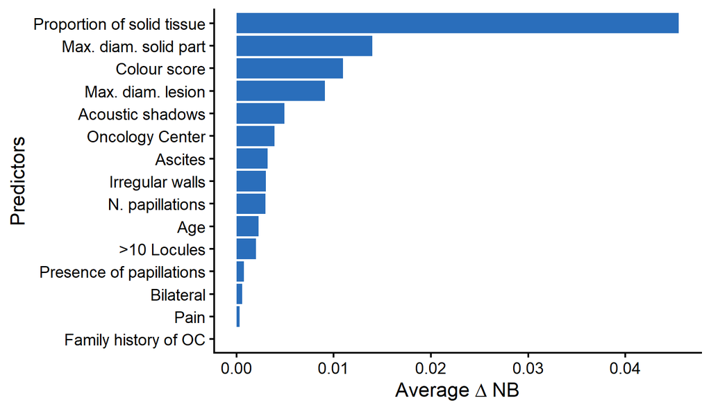

Figure 4: Figure S1. Variable importance according to average improvement in NB across the 10% best performing combinations for the ovarian cancer case study.

```r
vif_ADNEX <- VIF_plot(exhaustive_results$all_models, round(nrow(exhaustive_results$all_models)*0.1),data_dict = data_dict_adnex)$plot
ggsave(vif_ADNEX, filename = file.path(path_figures_paper, "Figure_S1.svg"), width = 5.5, height = 3.2, dpi = 300)
ggsave(vif_ADNEX, filename = file.path(path_figures_paper, "Figure_S1.pdf"), width = 5.5, height = 3.2, dpi = 300)
vif_ADNEX
```

Figure 4 shows the variable importance plot based on the average net benefit contribution of the models in which each predictor is included (limited to the best performing 10% of combinations). The predictors are ranked from most to least important based on their contribution to the net benefit.

**Plot all-subset model performance using raw and adjusted net benefit**

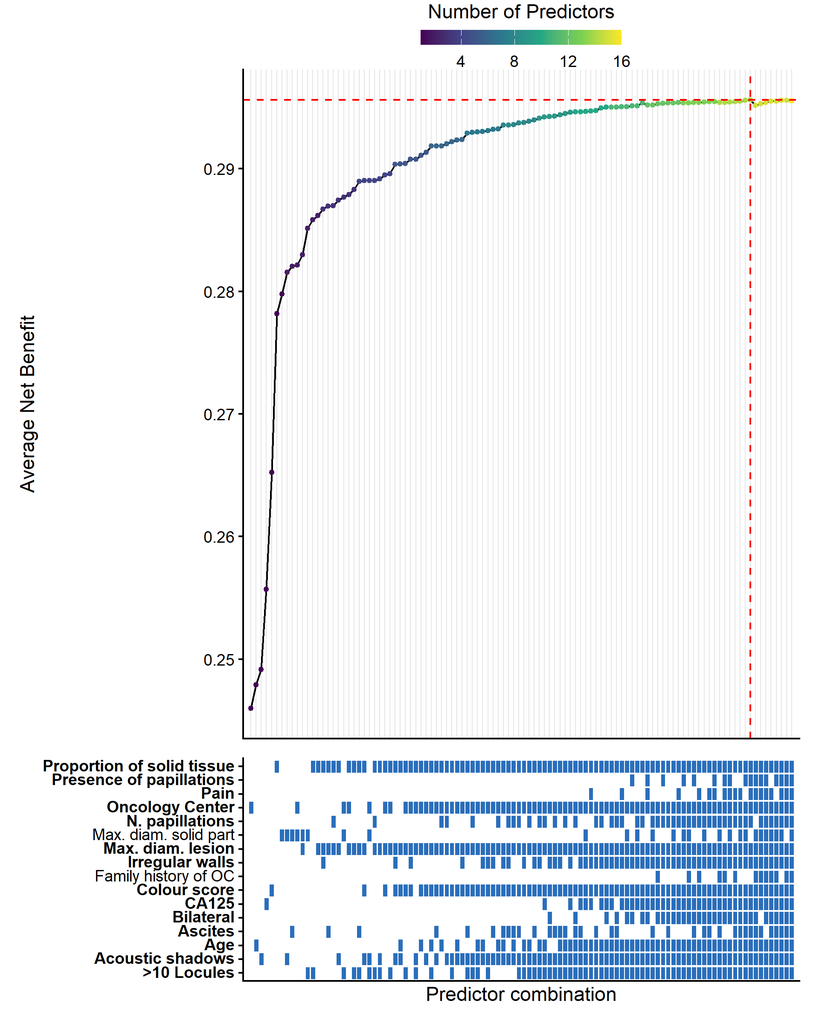

Figure 5: Figure S3. All subset plot for the ovarian cancer case study ignoring harms. Terms in bold are the included predictors.

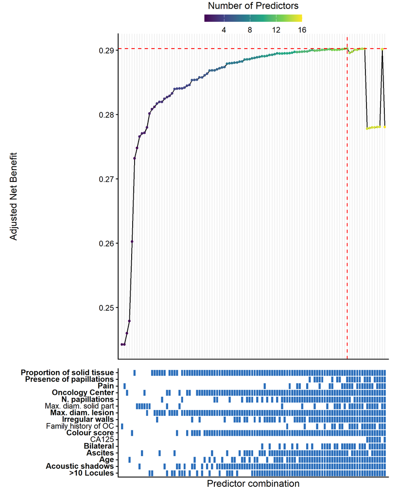

Figure 6: Figure S4. All subset plot for the ovarian cancer case study accounting for harms. Terms in bold are the included predictors.

```r
all_subset_ADNEX <- all_subset_plot(exhaustive_results$all_models,filter = 7, size_dot = 1,data_dict = data_dict_adnex)
all_subset_ADNEX
all_subset_ADNEX_adj <- all_subset_plot(exhaustive_results$all_models,filter = 7, size_dot = 1, metric = "Avg_Adj_Net_Benefit", y_axis = "Adjusted Net Benefit", data_dict = data_dict_adnex)
all_subset_ADNEX_adj

all_subset_ADNEX_adj_svg <- all_subset_plot(exhaustive_results$all_models,filter = 4, size_dot = 1, metric = "Avg_Adj_Net_Benefit", y_axis = "Adjusted Net Benefit", data_dict = data_dict_adnex)
all_subset_ADNEX |> ggsave(filename = file.path(path_figures_paper, "Figure_S3.svg"), width = 6.4, height = 8, dpi = 300)
all_subset_ADNEX |> ggsave(filename = file.path(path_figures_paper, "Figure_S3.pdf"), width = 6.4, height = 8, dpi = 300)
all_subset_ADNEX_adj |> ggsave(filename = file.path(path_figures_paper, "Figure_S4.svg"), width = 6.4, height = 8, dpi = 300)
all_subset_ADNEX_adj |> ggsave(filename = file.path(path_figures_paper, "Figure_S4.pdf"), width = 6.4, height = 8, dpi = 300)
```

## 4.4 Model fitting

**Fit full, backward-elimination, LASSO, and net-benefit models for comparison**

```r
## Full model -----

labs_full <- NBvarsel:::get_term_labels(vars_adnex[-1], data = training_data_oc, n_knots = 3)
fmla_full <- reformulate(termlabels = labs_full, response = "malignant")
model_full <- lrm(fmla_full, data = training_data_oc)
test_data_oc$full_malignant <- predict(model_full, newdata = test_data_oc, type = "fitted")

## Backward elimination -----
preds <- setdiff(vars, "malignant")
labs <- NBvarsel:::get_term_labels(preds, data = training_data_oc, n_knots = 3)
fmla     <- reformulate(termlabels = labs, response = "malignant")

model <- lrm(fmla, data = training_data_oc)
modelbw <- fastbw(model)
labs_bw <- NBvarsel:::get_term_labels(modelbw$names.kept, data = training_data_oc, n_knots = 3)
model_bw <- lrm(reformulate(termlabels = labs_bw, response = "malignant"), data = training_data_oc)
test_data_oc$bw_malignant <- predict(model_bw, newdata = test_data_oc, type = "fitted")

## Run lasso ####
x <- model.matrix(malignant ~ ., data = training_data_oc |> select(vars_adnex))[, -1]

y <- training_data_oc$malignant
x_test <- test_data_oc |> select(vars_adnex) |> select(-malignant) |> as.matrix()
y_test <- test_data_oc$malignant

set.seed(123)
cv_lasso <- cv.glmnet(x, y, alpha = 1, family = "binomial", nfolds = 10)
best_lambda <- cv_lasso$lambda.min
final_coefs <- coef(cv_lasso, s = "lambda.min")
clean_coefs <- final_coefs |>
  as.matrix() |>
  as.data.frame() |>
  tibble::rownames_to_column(var = "Predictor") |>
  arrange(desc(lambda.min))
test_predictions <- predict(cv_lasso, newx = x_test, s = "lambda.min")
test_data_oc$lasso_malignant <- as.vector(plogis(test_predictions))


predictors <- exhaustive_results$all_models |>
  arrange(-Avg_Net_Benefit) |> slice(1) |> pull(Model) |>
  str_split(pattern = ",", simplify = TRUE) |> as.vector() |> str_trim()

predictors_adj <- str_trim(str_split(exhaustive_results$best_model_stats$Model, pattern = ",", simplify = TRUE))

term_labs     <- NBvarsel:::get_term_labels(predictors, training_data_oc, 3)
term_labs_adj <- NBvarsel:::get_term_labels(predictors_adj, training_data_oc, 3)

outcome_var <- "malignant"
fmla     <- reformulate(termlabels = term_labs, response = outcome_var)
fmla_adj <- reformulate(termlabels = term_labs_adj, response = outcome_var)

model_NB     <- lrm(formula = fmla, data = training_data_oc)
model_adj_NB <- lrm(formula = fmla_adj, data = training_data_oc)

test_data_oc[, c("lp", "se.fit")]         <- predict(model_NB, se.fit = TRUE, newdata = test_data_oc)
test_data_oc[, "predictions"]             <- plogis(test_data_oc$lp)
test_data_oc[, c("lp_adj", "se.fit_adj")] <- predict(model_adj_NB, se.fit = TRUE, newdata = test_data_oc)
test_data_oc[, "predictions_adj"]         <- plogis(test_data_oc$lp_adj)
## Predictors selected by the best model in the exhaustive search
best_adj_NB <- exhaustive_results$best_model_stats
best_NB <- exhaustive_results$all_models |>
  filter(Avg_Net_Benefit == max(Avg_Net_Benefit)) |>
  slice(1)
preds_best_nb <- unlist(str_split(best_NB$Model, simplify = F, pattern = ", "))
preds_best_adj <- unlist(str_split(exhaustive_results$best_model_stats$Model,simplify = F, pattern = ", "))
```

## 4.6 Performance

### 4.6.1 Discrimination

**Calculate AUC values for all ovarian cancer models**

```r
AUC_NB    <- Metrics::auc(test_data_oc$malignant,test_data_oc$predictions)
AUC_NB_adj <- Metrics::auc(test_data_oc$malignant,test_data_oc$predictions_adj)
AUC_lasso <- Metrics::auc(test_data_oc$malignant,test_data_oc$lasso_malignant)
AUC_bw    <- Metrics::auc(test_data_oc$malignant,test_data_oc$bw_malignant)
AUC_ADNEXw <- Metrics::auc(test_data_oc$malignant,test_data_oc$pmalw)
AUC_ADNEXwo <- Metrics::auc(test_data_oc$malignant,test_data_oc$pmalwo)

AUC_full <- Metrics::auc(test_data_oc$malignant,test_data_oc$full_malignant)
delta_AUC <- AUC_NB_adj - AUC_full
```

The AUC for the NB model is 0.961, for the adjusted NB model is 0.959, for the ADNEX model with CA125 is 0.953, for the ADNEX model without CA125 is 0.950, for the LASSO model is 0.955, for the backward elimination model is 0.961, and for the full model is 0.961.

### 4.6.2 Clustered calibration

**Calculate clustered calibration curves for all ovarian cancer models**

```r
# library(calibrationCurves)

clus_cal <- valProbCluster(p = predictions, y = malignant, cluster = center, data = test_data_oc, approach = "MAC2")


clus_cal_adj <- valProbCluster(p = predictions_adj, y = malignant, cluster = center, data = test_data_oc, approach = "MAC2")


clus_cal_adnex <- valProbCluster(
  p = test_data_oc$pmalw, y = test_data_oc$malignant, cluster = test_data_oc$center,
  approach = "MAC2", method_choice = "splines", knots = 3
)

clus_cal_adnexwo <- valProbCluster(
  p = test_data_oc$pmalwo, y = test_data_oc$malignant, cluster = test_data_oc$center,
  approach = "MAC2", method_choice = "splines", knots = 3
)

clus_cal_lasso <- valProbCluster(p = test_data_oc$lasso_malignant, y = test_data_oc$malignant, cluster = test_data_oc$center, approach = "MAC2")
clus_cal_bw <- valProbCluster(p = test_data_oc$bw_malignant, y = test_data_oc$malignant, cluster = test_data_oc$center, approach = "MAC2")

clus_cal_full <- valProbCluster(p = test_data_oc$full_malignant, y = test_data_oc$malignant, cluster = test_data_oc$center, approach = "MAC2")

all_cal_data <- rbind(clus_cal$results$plot_data |> mutate(Model = "NBvarsel"),
                      clus_cal_adj$results$plot_data |> mutate(Model = "NBvarsel (Adj. NB)"),
                      clus_cal_adnex$results$plot_data |> mutate(Model = "ADNEX with CA125"),
                      clus_cal_adnexwo$results$plot_data |> mutate(Model = "ADNEX without CA125"),
                      clus_cal_lasso$results$plot_data |> mutate(Model = "LASSO"),
                      clus_cal_bw$results$plot_data |> mutate(Model = "BE"),
                      clus_cal_full$results$plot_data |> mutate(Model = "Full model"))

calcombined <- ggplot(all_cal_data, aes(x = x, y = y, color = Model, group = Model)) +
  geom_line(lwd = 1, lty = "solid") +
  theme_classic() +
  labs(x = "Estimated Probability", y = "Observed Proportion") +
  geom_abline(intercept = 0, slope = 1, linetype = "solid", color = "gray") +
  scale_color_manual(values = global_model_colors) +
  theme(legend.position = c(0.85, 0.30), legend.text = element_text(size = 10), text = element_text(size = 12))
```

**Plot predicted-probability distributions by malignancy status and model**

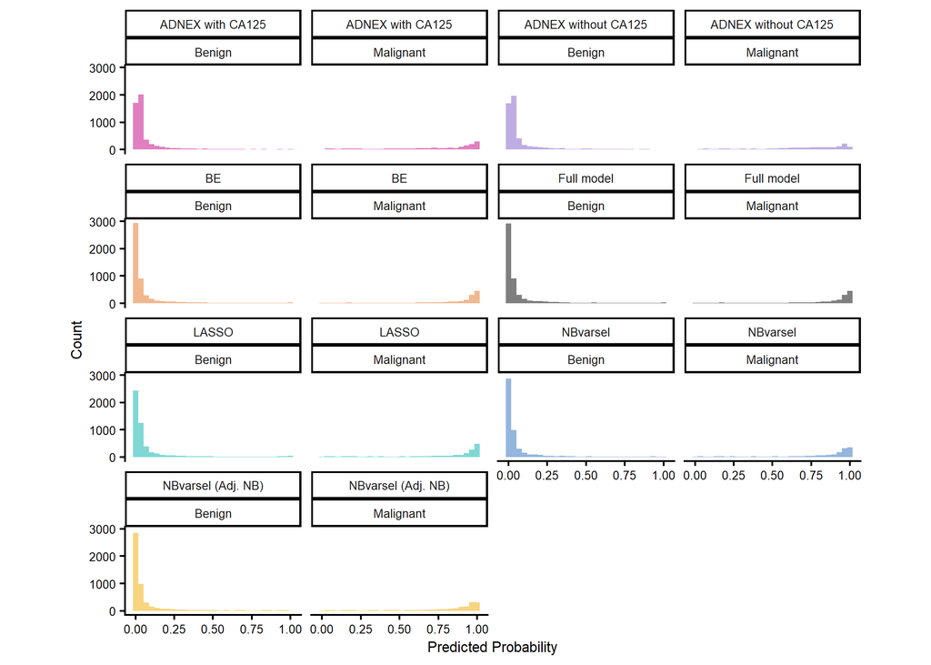

Figure 7: Online Only Figure 2. Distribution of the predicted probabilities for the different models in the ovarian cancer case study.

```r
preds_plot_data <- test_data_oc %>%
  select(malignant, predictions, predictions_adj, pmalw, pmalwo, lasso_malignant, bw_malignant, full_malignant) %>%
  pivot_longer(cols = -malignant, names_to = "Model", values_to = "Predicted_Probability") %>%
  mutate(Model = recode(Model,
                        predictions = "NBvarsel",
                        predictions_adj = "NBvarsel (Adj. NB)",
                        pmalw = "ADNEX with CA125",
                        pmalwo = "ADNEX without CA125",
                        lasso_malignant = "LASSO",
                        bw_malignant = "BE",
                        full_malignant = "Full model"),
         malignant = factor(malignant, levels = c(0, 1), labels = c("Benign", "Malignant")))
plot_dist_OC <- ggplot(preds_plot_data, aes(x = Predicted_Probability, fill = Model)) +
  geom_histogram(position = "identity", alpha = 0.5, bins = 30, show.legend = F) +
  facet_wrap(Model~ malignant, ncol = 4) +
  theme_classic() +
  labs(x = "Predicted Probability", y = "Count") +
  scale_fill_manual(values = global_model_colors) +
  theme(legend.position = "bottom", legend.text = element_text(size = 6), text = element_text(size = 8),
        aspect.ratio = 0.5)
plot_dist_OC
plot_dist_OC |> ggsave(path = path_figures_paper, filename = "Online_Only_Figure_2.svg", width = 6.5, height = 4.5, dpi = 300)
plot_dist_OC |> ggsave(path = path_figures_paper, filename = "Online_Only_Figure_2.pdf", width = 6.5, height = 4.5, dpi = 300)
```

**Combine and save the ovarian cancer calibration curves**

```r
calcombined |> ggsave(path = path_figures_paper, filename = "Figure_S2.svg", width = 6.5, height = 4.5, dpi = 300)
calcombined |> ggsave(path = path_figures_paper, filename = "Figure_S2.pdf", width = 6.5, height = 4.5, dpi = 300)
calcombined |> plotly::ggplotly() |> plotly::layout(hovermode = "x")
```

[interactive chart not shown]

Figure 8: Figure S2. Overall calibration of the clustered calibration plot for the ovarian cancer case study calculated with 2MA-C method. Histograms of predicted risks are available in the report. BE: Backward elimination; NB: Net Benefit.

### 4.6.3 Decision curve analysis

**Calculate raw and cost-adjusted decision curves for all ovarian cancer models**

```r
preds_ADNEX <- c("age", "oncology_center", "max_diam_lesion", "papillary_count",
                 "acoustic_shadows", "ascites", "locules_gt_10", "prop_solid", "ca125")



dca_plot <- dca(
  malignant ~ predictions + pmalw + pmalwo+ predictions_adj+ bw_malignant + lasso_malignant + full_malignant,
  data = test_data_oc,
  thresholds = seq(0, 0.30, by = 0.01),
  label = list(
    predictions     = "NBvarsel",
    pmalw           = "ADNEX with CA125",
    pmalwo         = "ADNEX without CA125",
    predictions_adj = "NBvarsel (Adj. NB)",
    bw_malignant   = "BE",
    lasso_malignant = "LASSO",
    full_malignant = "Full model"

  )
) |>
  plot(smooth = TRUE) + theme_classic(base_size = 12) +scale_color_manual(values = global_model_colors)


cost_adnex <- NBvarsel:::calculate_model_cost(preds_ADNEX, grouped_costs)
cost_adnexwo <- NBvarsel:::calculate_model_cost(setdiff(preds_ADNEX, "ca125"), grouped_costs)
cost_adjust_NB <- NBvarsel:::calculate_model_cost(preds_best_adj, grouped_costs)
cost_NB <- NBvarsel:::calculate_model_cost(preds_best_nb, grouped_costs)
cost_lasso <- NBvarsel:::calculate_model_cost(clean_coefs$Predictor[clean_coefs$lambda.min != 0], grouped_costs)
cost_bw <- NBvarsel:::calculate_model_cost(modelbw$names.kept, grouped_costs)
cost_full <- NBvarsel:::calculate_model_cost(vars_adnex[-1], grouped_costs)


dca_data <- dca_plot$data

dca_data <- dca_data |> mutate(cost =case_when(label == "NBvarsel" ~ cost_NB,
                             label == "NBvarsel (Adj. NB)" ~ cost_adjust_NB,
                             label == "ADNEX with CA125" ~ cost_adnex,
                             label == "ADNEX without CA125" ~ cost_adnexwo,
                             label == "LASSO" ~ cost_lasso,
                             label == "BE" ~ cost_bw,
                             label == "Full model" ~ cost_full,
                             TRUE ~ 0)) |> mutate(`Adjusted Net Benefit` = net_benefit - cost)
# dca_data |> filter(threshold == 0.1) |> select(label, net_benefit, `Adjusted Net Benefit`, cost) |> gt() |> fmt_number(decimals = 3)

dca <- ggplot(dca_data , aes(x = threshold , y = net_benefit, color = label, group = label)) +
  geom_line(lwd = 0.7) +
  theme_classic(base_size = 12) +
  labs(x = "Decision Threshold", y = "Net Benefit") +
  scale_color_manual(values = global_model_colors, name = "Strategy") +
  theme(legend.text = element_text(size = 9),
        legend.title = element_text(size = 9),
        legend.key.size = unit(0.3, "cm"),
        legend.margin = margin(t = 0, r = 0, b = 0, l = 0, unit = "pt"),
        legend.box.margin = margin(t = 0, r = 0, b = 0, l = 0, unit = "pt"))+ coord_cartesian(xlim = c(0, 0.20), y = c(-0.01, 0.25))

dca_adj <- ggplot(dca_data , aes(x = threshold , y = `Adjusted Net Benefit`, color = label, group = label)) +
  geom_line(lwd = 0.7) +
  theme_classic(base_size = 12) +
  labs(x = "Decision Threshold", y = "Adjusted Net Benefit") +
  scale_color_manual(values = global_model_colors, name = "Model") +
  theme(legend.text = element_text(size = 10))+ coord_cartesian(xlim = c(0, 0.20), y = c(-0.01, 0.25))


dca |> ggsave(filename = file.path(path_figures_paper, "Figure_2_left.svg"), width = 6.4, height = 4.5, dpi = 300)
dca |> ggsave(filename = file.path(path_figures_paper, "Figure_2_left.pdf"), width = 6.4, height = 4.5, dpi = 300)
dca_adj |> ggsave(filename = file.path(path_figures_paper, "Figure_2_right.svg"), width = 6.4, height = 4.5, dpi = 300)
dca_adj |> ggsave(filename = file.path(path_figures_paper, "Figure_2_right.pdf"), width = 6.4, height = 4.5, dpi = 300)

dca |> plotly::ggplotly() |>  plotly::layout(hovermode = "x")
dca_adj |> plotly::ggplotly() |> plotly::layout(hovermode = "x")
```

[interactive chart not shown]

Figure 9: Figure 2 (left). Decision curve analysis for unadjusted net benefit for the different variable selection procedures.

[interactive chart not shown]

Figure 10: Figure 2 (right). Decision curve analysis for harm-adjusted net benefit for the different variable selection procedures.

### 4.6.4 Performance summary ovarian cancer

**Calculate and tabulate ovarian cancer discrimination, calibration, and net-benefit metrics**

```r
OE_be <- sum(test_data_oc$malignant)/sum(test_data_oc$bw_malignant)
OE_lasso <- sum(test_data_oc$malignant)/sum(test_data_oc$lasso_malignant)
OE_nb <- sum(test_data_oc$malignant)/sum(test_data_oc$predictions)
OE_adj_nb <- sum(test_data_oc$malignant)/sum(test_data_oc$predictions_adj)
OE_full <- sum(test_data_oc$malignant)/sum(test_data_oc$full_malignant)
delta_OE_be <-  abs(1-OE_full) - abs(1-OE_adj_nb)

brier_nb <- mean((test_data_oc$malignant - test_data_oc$predictions)^2)
brier_adj_nb <- mean((test_data_oc$malignant - test_data_oc$predictions_adj)^2)
brier_lasso <- mean((test_data_oc$malignant - test_data_oc$lasso_malignant)^2)
brier_bw <- mean((test_data_oc$malignant - test_data_oc$bw_malignant)^2)
brier_full <- mean((test_data_oc$malignant - test_data_oc$full_malignant)^2)

nb_nb <- dca_data |> filter(label == "NBvarsel", threshold >= 0.01 & threshold <= 0.20) |> pull(`Adjusted Net Benefit`) |> mean()
nb_adj_nb <- dca_data |> filter(label == "NBvarsel (Adj. NB)", threshold >= 0.01 & threshold <= 0.20) |> pull(`Adjusted Net Benefit`) |> mean()
nb_lasso <- dca_data |> filter(label == "LASSO", threshold >= 0.01 & threshold <= 0.20) |> pull(`Adjusted Net Benefit`) |> mean()
nb_bw <- dca_data |> filter(label == "BE", threshold >= 0.01 & threshold <= 0.20) |> pull(`Adjusted Net Benefit`) |> mean()
nb_full <- dca_data |> filter(label == "Full model", threshold >= 0.01 & threshold <= 0.20) |> pull(`Adjusted Net Benefit`) |> mean()
nb_adnex <- dca_data |> filter(label == "ADNEX with CA125", threshold >= 0.01 & threshold <= 0.20) |> pull(`Adjusted Net Benefit`) |> mean()
nb_adnexwo <- dca_data |> filter(label == "ADNEX without CA125", threshold >= 0.01 & threshold <= 0.20) |> pull(`Adjusted Net Benefit`) |> mean()


nb_nb_raw <- dca_data |> filter(label == "NBvarsel", threshold >= 0.01 & threshold <= 0.20) |> pull(net_benefit) |> mean()
nb_adj_nb_raw <- dca_data |> filter(label == "NBvarsel (Adj. NB)", threshold >= 0.01 & threshold <= 0.20) |> pull(net_benefit) |> mean()
nb_lasso_raw <- dca_data |> filter(label == "LASSO", threshold >= 0.01 & threshold <= 0.20) |> pull(net_benefit) |> mean()
nb_bw_raw <- dca_data |> filter(label == "BE", threshold >= 0.01 & threshold <= 0.20) |> pull(net_benefit) |> mean()
nb_full_raw <- dca_data |> filter(label == "Full model", threshold >= 0.01 & threshold <= 0.20) |> pull(net_benefit) |> mean()
nb_adnex_raw <- dca_data |> filter(label == "ADNEX with CA125", threshold >= 0.01 & threshold <= 0.20) |> pull(net_benefit) |> mean()
nb_adnexwo_raw <- dca_data |> filter(label == "ADNEX without CA125", threshold >= 0.01 & threshold <= 0.20) |> pull(net_benefit) |> mean()


ADNEX_tbl <- tibble(
  Model = c(
    "NBvarsel",
    "NBvarsel (Adj. NB)",
    "ADNEX with CA125",
    "ADNEX without CA125",
    "LASSO",
    "BE",
    "Full model",
    "Delta (Adj. NB - Full model)"
  ),
  AUC = c(
    AUC_NB,
    AUC_NB_adj,
    AUC_ADNEXw,
    AUC_ADNEXwo,
    AUC_lasso,
    AUC_bw,
    AUC_full,
    delta_AUC
  ),
  OE = c(
    OE_nb,
    OE_adj_nb,
    sum(test_data_oc$malignant) / sum(test_data_oc$pmalw),
    sum(test_data_oc$malignant) / sum(test_data_oc$pmalwo),
    OE_lasso,
    OE_be,
    OE_full,
    delta_OE_be
  ),
  Brier = c(
    brier_nb,
    brier_adj_nb,
    mean((test_data_oc$malignant - test_data_oc$pmalw)^2),
    mean((test_data_oc$malignant - test_data_oc$pmalwo)^2),
    brier_lasso,
    brier_bw,
    brier_full,
    brier_full - brier_adj_nb
  ),
  `Net benefit` = c(
    nb_nb_raw,
    nb_adj_nb_raw,
    nb_adnex_raw,
    nb_adnexwo_raw,
    nb_lasso_raw,
    nb_bw_raw,
    nb_full_raw,
    nb_adj_nb_raw - nb_full_raw
  ),
  Cost = c(
    cost_NB,
    cost_adjust_NB,
    cost_adnex,
    cost_adnexwo,
    cost_lasso,
    cost_bw,
    cost_full,
    cost_adjust_NB - cost_full
  ),
  `Adj. NB` = c(
    nb_nb,
    nb_adj_nb,
    nb_adnex,
    nb_adnexwo,
    nb_lasso,
    nb_bw,
    nb_full,
    nb_adj_nb - nb_full
  )
)

ADNEX_tbl_gt <- ADNEX_tbl |>
  gt() |>
  fmt_number(
    columns = c(AUC, OE,Brier, `Adj. NB`, `Net benefit`, Cost),
    decimals = 3
  ) |>

  # Optional: align the Model text to the left so it looks nicer
  cols_align(
    align = "left",
    columns = Model
  )
ADNEX_tbl_gt
ADNEX_tbl_gt |> tab_caption("Table 2. Performance metrics of the different models in the test set varying the variable selection procedure.") |> force_gtsave(filename = "Table_2.docx")
```

Table 6: Table 2. Performance metrics of the different models in the test set varying the variable selection procedure.

| Model | AUC | OE | Brier | Net benefit | Cost | Adj. NB |
| --- | --- | --- | --- | --- | --- | --- |
| NBvarsel | 0.961 | 0.975 | 0.063 | 0.225 | 0.018 | 0.207 |
| NBvarsel (Adj. NB) | 0.959 | 0.975 | 0.065 | 0.225 | 0.005 | 0.220 |
| ADNEX with CA125 | 0.953 | 1.031 | 0.070 | 0.222 | 0.018 | 0.204 |
| ADNEX without CA125 | 0.950 | 1.066 | 0.074 | 0.221 | 0.005 | 0.216 |
| LASSO | 0.955 | 0.940 | 0.069 | 0.223 | 0.018 | 0.206 |
| BE | 0.961 | 0.957 | 0.064 | 0.225 | 0.018 | 0.208 |
| Full model | 0.961 | 0.956 | 0.064 | 0.225 | 0.018 | 0.208 |
| Delta (Adj. NB - Full model) | −0.001 | 0.019 | −0.001 | 0.000 | −0.012 | 0.012 |

**Create a decision-threshold table of adjusted net benefit for each ovarian cancer model**

```r
tbl_ADNEX <- dca_data |>
  pivot_wider(names_from = label, values_from = `Adjusted Net Benefit`, id_cols = threshold) |>
  rowwise() |>
  mutate(
    # Added na.rm = TRUE just in case your DCA data has missing net benefits at certain thresholds
    max_val = max(c_across(c(`Treat All`, `Treat None`, `ADNEX with CA125`, `ADNEX without CA125`, `NBvarsel`, `NBvarsel (Adj. NB)`,`BE`,`LASSO`, `Full model`)), na.rm = TRUE)
  ) |>
  ungroup() |>
  gt() |>
  fmt_number(
    columns = c(`Treat All`, `ADNEX with CA125`, `ADNEX without CA125`, `NBvarsel`, `NBvarsel (Adj. NB)`,`BE`,`LASSO`, `Full model`),
    decimals = 6
  ) |>
  fmt_number(
    columns = `Treat None`,
    decimals = 0
  ) |>

  # --- Apply the Green Highlights ---

  tab_style(
    style = cell_fill(color = "lightgreen"),
    locations = cells_body(columns = `Treat All`, rows = `Treat All` == max_val)
  ) |>
  tab_style(
    style = cell_fill(color = "lightgreen"),
    locations = cells_body(columns = `Treat None`, rows = `Treat None` == max_val)
  ) |>
  tab_style(
    style = cell_fill(color = "lightgreen"),
    locations = cells_body(columns = `ADNEX with CA125`, rows = `ADNEX with CA125` == max_val)
  ) |>
  tab_style(
    style = cell_fill(color = "lightgreen"),
    locations = cells_body(columns = `ADNEX without CA125`, rows = `ADNEX without CA125` == max_val)
  ) |>
  tab_style(
    style = cell_fill(color = "lightgreen"),
    locations = cells_body(columns = `NBvarsel`, rows = `NBvarsel` == max_val)
  ) |>
  tab_style(
    style = cell_fill(color = "lightgreen"),
    locations = cells_body(columns = `NBvarsel (Adj. NB)`, rows = `NBvarsel (Adj. NB)` == max_val)
  ) |>
  tab_style(
    style = cell_fill(color = "lightgreen"),
    locations = cells_body(columns = `Full model`, rows = `Full model` == max_val)
  ) |>
    tab_style(
    style = cell_fill(color = "lightgreen"),
    locations = cells_body(columns = `BE`, rows = `BE` == max_val)
  ) |>
    tab_style(
    style = cell_fill(color = "lightgreen"),
    locations = cells_body(columns = `LASSO`, rows = `LASSO` == max_val)
  ) |>

  # Hide the helper column
  cols_hide(columns = max_val)
tbl_ADNEX
tbl_ADNEX |> tab_caption("Online Only Table 4. Net benefit table for the ovarian cancer case study. The table shows the adjusted net benefit for each model at different decision thresholds.") |> force_gtsave(filename = "Online_Only_Table_4.docx")
```

Table 7: Online Only Table 4. Net benefit table for the ovarian cancer case study. The table shows the adjusted net benefit for each model at different decision thresholds.

| threshold | Treat All | Treat None | NBvarsel | ADNEX with CA125 | ADNEX without CA125 | NBvarsel (Adj. NB) | BE | LASSO | Full model |
| --- | --- | --- | --- | --- | --- | --- | --- | --- | --- |
| 0.00 | 0.250183 | 0 | 0.232683 | 0.232683 | 0.245183 | 0.245183 | 0.232683 | 0.232683 | 0.232683 |
| 0.01 | 0.242609 | 0 | 0.226777 | 0.225556 | 0.237932 | 0.239164 | 0.226953 | 0.226032 | 0.226942 |
| 0.02 | 0.234880 | 0 | 0.223353 | 0.221049 | 0.233427 | 0.236223 | 0.223633 | 0.222915 | 0.223619 |
| 0.03 | 0.226992 | 0 | 0.220938 | 0.218034 | 0.231043 | 0.233868 | 0.221152 | 0.220229 | 0.221175 |
| 0.04 | 0.218940 | 0 | 0.218601 | 0.216964 | 0.229081 | 0.231454 | 0.218613 | 0.218498 | 0.218601 |
| 0.05 | 0.210718 | 0 | 0.217071 | 0.215664 | 0.227918 | 0.229655 | 0.216840 | 0.216056 | 0.216663 |
| 0.06 | 0.202322 | 0 | 0.214367 | 0.213168 | 0.225655 | 0.226929 | 0.214582 | 0.213056 | 0.214370 |
| 0.07 | 0.193745 | 0 | 0.212638 | 0.211122 | 0.223969 | 0.224816 | 0.212418 | 0.211582 | 0.212542 |
| 0.08 | 0.184981 | 0 | 0.211563 | 0.208578 | 0.221815 | 0.223250 | 0.211404 | 0.209753 | 0.211474 |
| 0.09 | 0.176025 | 0 | 0.210096 | 0.206882 | 0.219454 | 0.221795 | 0.210303 | 0.208034 | 0.210188 |
| 0.10 | 0.166870 | 0 | 0.209023 | 0.204884 | 0.217563 | 0.220452 | 0.208795 | 0.206507 | 0.208552 |
| 0.11 | 0.157508 | 0 | 0.207027 | 0.203824 | 0.215599 | 0.218910 | 0.207449 | 0.204886 | 0.207322 |
| 0.12 | 0.147935 | 0 | 0.205172 | 0.201893 | 0.213078 | 0.217207 | 0.205644 | 0.203187 | 0.205504 |
| 0.13 | 0.138141 | 0 | 0.203087 | 0.199365 | 0.211180 | 0.215259 | 0.203971 | 0.201280 | 0.203884 |
| 0.14 | 0.128119 | 0 | 0.201472 | 0.197587 | 0.209591 | 0.213198 | 0.202308 | 0.198989 | 0.202236 |
| 0.15 | 0.117862 | 0 | 0.199211 | 0.195071 | 0.207931 | 0.211497 | 0.200251 | 0.197450 | 0.200157 |
| 0.16 | 0.107360 | 0 | 0.197186 | 0.193722 | 0.204915 | 0.210172 | 0.198486 | 0.195635 | 0.198514 |
| 0.17 | 0.096605 | 0 | 0.195579 | 0.191715 | 0.202849 | 0.208267 | 0.195535 | 0.194412 | 0.195621 |
| 0.18 | 0.085588 | 0 | 0.193702 | 0.189584 | 0.201101 | 0.206975 | 0.194001 | 0.192615 | 0.193887 |
| 0.19 | 0.074299 | 0 | 0.191821 | 0.187250 | 0.198842 | 0.205012 | 0.191798 | 0.190546 | 0.191875 |
| 0.20 | 0.062728 | 0 | 0.190766 | 0.185472 | 0.196731 | 0.202938 | 0.190511 | 0.188101 | 0.190912 |
| 0.21 | 0.050864 | 0 | 0.189300 | 0.183712 | 0.195472 | 0.200772 | 0.189439 | 0.185472 | 0.189585 |
| 0.22 | 0.038696 | 0 | 0.187875 | 0.181262 | 0.192725 | 0.199102 | 0.187845 | 0.184696 | 0.188471 |
| 0.23 | 0.026211 | 0 | 0.186605 | 0.179961 | 0.190534 | 0.197665 | 0.186319 | 0.183811 | 0.186465 |
| 0.24 | 0.013398 | 0 | 0.184917 | 0.177568 | 0.188515 | 0.196241 | 0.184686 | 0.182803 | 0.184832 |
| 0.25 | 0.000243 | 0 | 0.182977 | 0.175529 | 0.187590 | 0.195088 | 0.183221 | 0.181468 | 0.183172 |
| 0.26 | −0.013267 | 0 | 0.181226 | 0.173304 | 0.186139 | 0.194547 | 0.182106 | 0.179406 | 0.182011 |
| 0.27 | −0.027147 | 0 | 0.179865 | 0.171864 | 0.184094 | 0.193605 | 0.180645 | 0.177494 | 0.180591 |
| 0.28 | −0.041413 | 0 | 0.178385 | 0.170449 | 0.182811 | 0.191948 | 0.179667 | 0.176121 | 0.179439 |
| 0.29 | −0.056081 | 0 | 0.177060 | 0.169073 | 0.181036 | 0.190346 | 0.178323 | 0.173899 | 0.177998 |
| 0.30 | −0.071168 | 0 | 0.175786 | 0.168212 | 0.178939 | 0.188933 | 0.177246 | 0.172907 | 0.177142 |

# 5 MIMIC ED (Emergency Department risk)

**TipReproducible section**

This section is reproducible by obtaining the training and test data according to the guidelines of Xie et al. (see `https://github.com/nliulab/mimic4ed-benchmark/tree/main`) and running the code chunks in this section. The variable selection process is computationally intensive, so the results are saved as an RDS file to avoid rerunning the analysis in future renders.

**Load MIMIC IV ED data**

```r
# train_data and test_data are obtained following the guidelines of Xie et al. (2022) for the MIMIC IV ED benchmark
train_data <-load_mimic_ed(version = "train")
test_data <- load_mimic_ed(version = "test")
```

## 5.1 Dataset descriptives

**Define candidate predictors for the MIMIC IV ED case study**

```r
vars_mimic = c("age", "gender",

              "n_ed_30d", "n_ed_90d", "n_ed_365d", "n_hosp_30d", "n_hosp_90d",
              "n_hosp_365d", "n_icu_30d", "n_icu_90d", "n_icu_365d",

              "triage_temperature", "triage_heartrate", "triage_resprate",
              "triage_o2sat", "triage_sbp", "triage_dbp", "triage_pain", "triage_acuity",

              "chiefcom_chest_pain", "chiefcom_abdominal_pain", "chiefcom_headache",
              "chiefcom_shortness_of_breath", "chiefcom_back_pain", "chiefcom_cough",
              "chiefcom_nausea_vomiting", "chiefcom_fever_chills", "chiefcom_syncope",
              "chiefcom_dizziness",

              "cci_MI", "cci_CHF", "cci_PVD", "cci_Stroke", "cci_Dementia",
              "cci_Pulmonary", "cci_Rheumatic", "cci_PUD", "cci_Liver1", "cci_DM1",
              "cci_DM2", "cci_Paralysis", "cci_Renal", "cci_Cancer1", "cci_Liver2",
              "cci_Cancer2", "cci_HIV",

              "eci_Arrhythmia", "eci_Valvular", "eci_PHTN",  "eci_HTN1", "eci_HTN2",
              "eci_NeuroOther", "eci_Hypothyroid", "eci_Lymphoma", "eci_Coagulopathy",
              "eci_Obesity", "eci_WeightLoss", "eci_FluidsLytes", "eci_BloodLoss",
              "eci_Anemia", "eci_Alcohol", "eci_Drugs","eci_Psychoses", "eci_Depression")

outcome = "outcome_hospitalization"

data_dict_mimic <- c(
  # Demographics (eTable 1)
  "age"                          = "Age", #
  "gender"                       = "Gender", #

  # Patient History (eTable 1)
  "n_ed_30d"                     = "ED visits in the past month", #
  "n_ed_90d"                     = "ED visits in the past three months", #
  "n_ed_365d"                    = "ED visits in the past year", #
  "n_hosp_30d"                   = "Hospitalizations in the past month", #
  "n_hosp_90d"                   = "Hospitalizations in the past three months", #
  "n_hosp_365d"                  = "Hospitalizations in the past year", #
  "n_icu_30d"                    = "ICU admissions in the past month", #
  "n_icu_90d"                    = "ICU admissions in the past three months", #
  "n_icu_365d"                   = "ICU admissions in the past year", #

  # Triage Vital Signs (eTable 1 & 2)
  "triage_temperature"           = "Temperature (Celsius)",
  "triage_heartrate"             = "Heart rate (bpm)",
  "triage_resprate"              = "Respiratory rate (bpm)",
  "triage_o2sat"                 = "Oxygen saturation (%)",
  "triage_sbp"                   = "Systolic blood pressure (mmHg)",
  "triage_dbp"                   = "Diastolic blood pressure (mmHg)",
  "triage_pain"                  = "Pain scale",
  "triage_acuity"                = "Emergency Severity Index (ESI)",

  # Chief Complaints (eTable 1 summarizes these as "Top 10 chief complaints identified in the ED")
  "chiefcom_chest_pain"          = "Chest Pain",
  "chiefcom_abdominal_pain"      = "Abdominal Pain",
  "chiefcom_headache"            = "Headache",
  "chiefcom_shortness_of_breath" = "Shortness of Breath",
  "chiefcom_back_pain"           = "Back Pain",
  "chiefcom_cough"               = "Cough",
  "chiefcom_nausea_vomiting"     = "Nausea/Vomiting",
  "chiefcom_fever_chills"        = "Fever/Chills",
  "chiefcom_syncope"             = "Syncope",
  "chiefcom_dizziness"           = "Dizziness",

  # Comorbidities: Charlson Comorbidity Index (eTable 2)
  "cci_MI"                       = "Myocardial infarction",
  "cci_CHF"                      = "Congestive heart failure",
  "cci_PVD"                      = "Peripheral vascular disease",
  "cci_Stroke"                   = "Stroke",
  "cci_Dementia"                 = "Dementia",
  "cci_Pulmonary"                = "Chronic pulmonary disease",
  "cci_Rheumatic"                = "Rheumatoid disease",
  "cci_PUD"                      = "Peptic ulcer disease",
  "cci_Liver1"                   = "Mild liver disease",
  "cci_DM1"                      = "Diabetes without chronic complications",
  "cci_DM2"                      = "Diabetes with complications",
  "cci_Paralysis"                = "Hemiplegia",
  "cci_Renal"                    = "Moderate to severe chronic kidney disease",
  "cci_Cancer1"                  = "Local tumor, leukemia, and lymphoma",
  "cci_Liver2"                   = "Moderate/severe liver disease",
  "cci_Cancer2"                  = "Metastatic solid tumor",
  "cci_HIV"                      = "AIDS",


  "eci_Arrhythmia"               = "Cardiac arrhythmias",
  "eci_Valvular"                 = "Valvular disease",
  "eci_PHTN"                     = "Pulmonary circulation disorders",
  "eci_HTN1"                     = "Hypertension, uncomplicated",
  "eci_HTN2"                     = "Hypertension, complicated",
  "eci_NeuroOther"               = "Other neurological disorders",
  "eci_Hypothyroid"              = "Hypothyroidism",
  "eci_Lymphoma"                 = "Lymphoma",
  "eci_Coagulopathy"             = "Coagulopathy",
  "eci_Obesity"                  = "Obesity",
  "eci_WeightLoss"               = "Weight loss",
  "eci_FluidsLytes"              = "Fluid and electrolyte disorders",
  "eci_BloodLoss"                = "Blood loss anemia",
  "eci_Anemia"                   = "Deficiency anemia",
  "eci_Alcohol"                  = "Alcohol abuse",
  "eci_Drugs"                    = "Drug abuse",
  "eci_Psychoses"                = "Psychoses",
  "eci_Depression"               = "Depression",

  # Outcomes (eTable 1 & 2)
  "outcome_hospitalization"      = "Hospitalization" #
)

rename_dict_MIMIC <- stats::setNames(names(data_dict_mimic), data_dict_mimic)
```

**Create side-by-side predictor-distribution tables for the MIMIC-IV ED training and test sets**

```r
combined_data <- bind_rows(
  "Training Set" = train_data |> select(vars_mimic, outcome),
  "Testing Set"  = test_data |> select(vars_mimic, outcome),
  .id = "Dataset_Split"
)  |>   dplyr::rename(dplyr::any_of(rename_dict_MIMIC))


# 2. Build the side-by-side comparison table
comparison_table <- combined_data |>
  tbl_strata(
    strata = Dataset_Split,
    .tbl_fun = ~ .x |>
  tbl_summary(
    by = Hospitalization,
    type = c(`ICU admissions in the past month`, `ICU admissions in the past three months`, `ICU admissions in the past year`) ~ "continuous",
    statistic = c(
      all_continuous() ~ "{mean} ({sd})", # [{min}-{max}]",
      all_categorical() ~ "{n} ({p}%)"
    ),
    digits = list(all_continuous() ~ 2, all_categorical() ~ 0, `Temperature (Celsius)` ~ 2)
  )) |>  modify_header(
    all_stat_cols() ~ "**{level}**\nN = {n} ({style_number(p * 100, digits = 0)}%)"
  )
comparison_table
comparison_table |> modify_caption("Table S2. Predictor distribution by outcome for the MIMIC-ED case study.") |> as_flex_table() |> flextable::autofit() |> save_as_docx(path = file.path(path_tables_paper, "Table_S2.docx"))
```

Table 8: Table S2. Predictor distribution by outcome for the MIMIC-ED case study.

| **Characteristic** | **Testing Set** **FALSE** N = 43957 (53%)<sup>1</sup> | **Testing Set** **TRUE** N = 39648 (47%)<sup>1</sup> | **Training Set** **FALSE** N = 176269 (53%)<sup>1</sup> | **Training Set** **TRUE** N = 158151 (47%)<sup>1</sup> |
| --- | --- | --- | --- | --- |
| Age | 46.37 (19.40) | 60.03 (19.47) | 46.33 (19.37) | 60.09 (19.50) |
| Gender |  |  |  |  |
| F | 25,284 (58%) | 20,113 (51%) | 101,441 (58%) | 80,124 (51%) |
| M | 18,673 (42%) | 19,535 (49%) | 74,828 (42%) | 78,027 (49%) |
| ED visits in the past month | 0.22 (0.81) | 0.27 (0.80) | 0.21 (0.77) | 0.27 (0.80) |
| ED visits in the past three months | 0.46 (1.64) | 0.62 (1.65) | 0.46 (1.59) | 0.62 (1.62) |
| ED visits in the past year | 1.26 (4.27) | 1.63 (4.35) | 1.25 (4.17) | 1.60 (4.24) |
| Hospitalizations in the past month | 0.09 (0.41) | 0.23 (0.60) | 0.09 (0.41) | 0.23 (0.61) |
| Hospitalizations in the past three months | 0.21 (0.82) | 0.54 (1.22) | 0.21 (0.82) | 0.54 (1.21) |
| Hospitalizations in the past year | 0.61 (2.23) | 1.42 (3.17) | 0.61 (2.21) | 1.39 (3.12) |
| ICU admissions in the past month | 0.01 (0.11) | 0.03 (0.20) | 0.01 (0.10) | 0.03 (0.20) |
| ICU admissions in the past three months | 0.02 (0.18) | 0.08 (0.35) | 0.02 (0.16) | 0.08 (0.34) |
| ICU admissions in the past year | 0.05 (0.33) | 0.19 (0.64) | 0.05 (0.30) | 0.18 (0.63) |
| Temperature (Celsius) | 36.68 (0.48) | 36.75 (0.60) | 36.68 (0.49) | 36.75 (0.58) |
| Heart rate (bpm) | 83.91 (16.33) | 86.31 (18.55) | 83.89 (16.30) | 86.31 (18.56) |
| Respiratory rate (bpm) | 17.30 (2.33) | 17.88 (2.76) | 17.30 (2.05) | 17.86 (2.85) |
| Oxygen saturation (%) | 98.81 (1.79) | 97.95 (2.80) | 98.80 (2.04) | 97.95 (2.73) |
| Systolic blood pressure (mmHg) | 135.11 (20.71) | 134.51 (23.73) | 135.18 (20.67) | 134.51 (23.68) |
| Diastolic blood pressure (mmHg) | 78.74 (13.81) | 76.01 (15.61) | 78.77 (13.74) | 76.00 (15.58) |
| Pain scale | 4.67 (3.58) | 3.59 (3.53) | 4.67 (3.59) | 3.59 (3.55) |
| Emergency Severity Index (ESI) |  |  |  |  |
| 1 | 1,003 (2%) | 3,744 (9%) | 4,061 (2%) | 15,206 (10%) |
| 2 | 8,585 (20%) | 19,365 (49%) | 34,442 (20%) | 76,998 (49%) |
| 3 | 28,666 (65%) | 16,252 (41%) | 115,259 (65%) | 64,847 (41%) |
| 4 | 5,499 (13%) | 277 (1%) | 21,649 (12%) | 1,072 (1%) |
| 5 | 204 (0%) | 10 (0%) | 858 (0%) | 28 (0%) |
| Chest Pain | 2,596 (6%) | 3,226 (8%) | 10,489 (6%) | 12,815 (8%) |
| Abdominal Pain | 4,814 (11%) | 4,718 (12%) | 19,606 (11%) | 18,996 (12%) |
| Headache | 2,191 (5%) | 856 (2%) | 9,141 (5%) | 3,546 (2%) |
| Shortness of Breath | 72 (0%) | 157 (0%) | 308 (0%) | 684 (0%) |
| Back Pain | 2,312 (5%) | 976 (2%) | 9,446 (5%) | 3,973 (3%) |
| Cough | 983 (2%) | 804 (2%) | 4,039 (2%) | 2,963 (2%) |
| Nausea/Vomiting | 1,036 (2%) | 922 (2%) | 4,280 (2%) | 3,862 (2%) |
| Fever/Chills | 857 (2%) | 2,056 (5%) | 3,553 (2%) | 8,001 (5%) |
| Syncope | 840 (2%) | 718 (2%) | 3,334 (2%) | 2,883 (2%) |
| Dizziness | 1,191 (3%) | 878 (2%) | 4,860 (3%) | 3,502 (2%) |
| Myocardial infarction | 1,195 (3%) | 3,488 (9%) | 4,997 (3%) | 13,954 (9%) |
| Congestive heart failure | 1,972 (4%) | 5,813 (15%) | 7,855 (4%) | 23,195 (15%) |
| Peripheral vascular disease | 1,083 (2%) | 3,095 (8%) | 4,385 (2%) | 12,417 (8%) |
| Stroke | 1,202 (3%) | 2,828 (7%) | 4,944 (3%) | 11,137 (7%) |
| Dementia | 369 (1%) | 1,046 (3%) | 1,571 (1%) | 4,016 (3%) |
| Chronic pulmonary disease | 4,407 (10%) | 7,598 (19%) | 17,602 (10%) | 29,854 (19%) |
| Rheumatoid disease | 568 (1%) | 1,126 (3%) | 2,290 (1%) | 4,683 (3%) |
| Peptic ulcer disease | 419 (1%) | 1,118 (3%) | 1,713 (1%) | 4,522 (3%) |
| Mild liver disease | 1,751 (4%) | 3,791 (10%) | 7,157 (4%) | 15,257 (10%) |
| Diabetes without chronic complications | 3,782 (9%) | 7,239 (18%) | 15,159 (9%) | 29,311 (19%) |
| Diabetes with complications | 1,495 (3%) | 3,810 (10%) | 6,004 (3%) | 15,442 (10%) |
| Hemiplegia | 304 (1%) | 677 (2%) | 1,205 (1%) | 2,697 (2%) |
| Moderate to severe chronic kidney disease | 2,151 (5%) | 6,084 (15%) | 8,405 (5%) | 24,193 (15%) |
| Local tumor, leukemia, and lymphoma | 1,482 (3%) | 4,018 (10%) | 5,814 (3%) | 15,682 (10%) |
| Moderate/severe liver disease | 391 (1%) | 1,299 (3%) | 1,504 (1%) | 5,312 (3%) |
| Metastatic solid tumor | 476 (1%) | 1,619 (4%) | 1,931 (1%) | 6,419 (4%) |
| AIDS | 316 (1%) | 468 (1%) | 1,196 (1%) | 1,938 (1%) |
| Cardiac arrhythmias | 3,562 (8%) | 8,250 (21%) | 14,311 (8%) | 32,344 (20%) |
| Valvular disease | 1,177 (3%) | 3,110 (8%) | 4,655 (3%) | 12,278 (8%) |
| Pulmonary circulation disorders | 1,057 (2%) | 2,889 (7%) | 4,242 (2%) | 11,041 (7%) |
| Hypertension, uncomplicated | 2,275 (5%) | 6,301 (16%) | 8,735 (5%) | 25,145 (16%) |
| Hypertension, complicated | 7,473 (17%) | 12,965 (33%) | 30,255 (17%) | 51,698 (33%) |
| Other neurological disorders | 2,062 (5%) | 4,277 (11%) | 8,431 (5%) | 16,790 (11%) |
| Hypothyroidism | 1,902 (4%) | 3,689 (9%) | 7,564 (4%) | 14,817 (9%) |
| Lymphoma | 248 (1%) | 694 (2%) | 920 (1%) | 2,639 (2%) |
| Coagulopathy | 1,560 (4%) | 4,411 (11%) | 6,346 (4%) | 17,264 (11%) |
| Obesity | 2,768 (6%) | 4,621 (12%) | 11,238 (6%) | 18,236 (12%) |
| Weight loss | 1,276 (3%) | 3,233 (8%) | 4,894 (3%) | 12,810 (8%) |
| Fluid and electrolyte disorders | 4,841 (11%) | 10,826 (27%) | 19,235 (11%) | 43,562 (28%) |
| Blood loss anemia | 307 (1%) | 820 (2%) | 1,310 (1%) | 3,341 (2%) |
| Deficiency anemia | 1,638 (4%) | 3,375 (9%) | 6,614 (4%) | 13,648 (9%) |
| Alcohol abuse | 2,311 (5%) | 4,122 (10%) | 9,384 (5%) | 16,602 (10%) |
| Drug abuse | 2,118 (5%) | 3,469 (9%) | 8,711 (5%) | 13,647 (9%) |
| Psychoses | 897 (2%) | 1,456 (4%) | 3,526 (2%) | 5,793 (4%) |
| Depression | 5,176 (12%) | 8,586 (22%) | 20,807 (12%) | 33,957 (21%) |

<sup>1</sup> Mean (SD); n (%)

## 5.2 Baseline model

**Fit the ridge-regression baseline and calculate test-set predictions and AUC**

```r
x_mat <- model.matrix(~ . - 1, data = train_data[, vars_mimic])
newx_matrix <- model.matrix(~ . - 1, data = test_data[, vars_mimic])

y_vec <- as.factor(train_data[[outcome]])


logreg_model <- glmnet(x_mat, y_vec, family = "binomial", alpha = 0)


preds_ridge <- as.data.frame(predict(logreg_model, newx = newx_matrix, type = "response", s = 0))


auc_ridge <- pROC::roc(test_data[[outcome]], preds_ridge$`s=0`, quiet = TRUE)$auc


y_calib <- ifelse(test_data[[outcome]] == levels(y_vec)[2], 1, 0)

calibration <- valProbggplot(y = y_calib, p = preds_ridge$`s=0`, smooth = "rcs")
test_data$preds_baseline <- preds_ridge$`s=0`
```

## 5.3 Minimum sample size analysis

**Calculate the required sample size for the MIMIC-IV ED case study**

```r
sample_size_mimic <- pmsampsize(type = "b", parameters =nrow(coef(logreg_model)), prevalence = mean(train_data$outcome_hospitalization), cstat = 0.806, shrinkage = 0.9,  seed = 1)

sample_size_mimic$results_table |>
  as.data.frame() |>
  gt(rownames_to_stub = TRUE) |>
  tab_stubhead(label = "Criteria") |>
  tab_header(title = "Sample Size Calculation for MIMIC IV ED Case Study")
```

Table 9: Online Only Table 5. Minimum sample size calculation for the MIMIC-ED case study.

Sample Size Calculation for MIMIC IV ED Case Study

| Criteria | Samp_size | Shrinkage | Parameter | CS_Rsq | Max_Rsq | Nag_Rsq | EPP |
| --- | --- | --- | --- | --- | --- | --- | --- |
| Criteria 1 | 1848 | 0.900 | 66 | 0.2703 | 0.749 | 0.361 | 13.24 |
| Criteria 2 | 1475 | 0.878 | 66 | 0.2703 | 0.749 | 0.361 | 10.57 |
| Criteria 3 | 384 | 0.900 | 66 | 0.2703 | 0.749 | 0.361 | 2.75 |
| Final | 1848 | 0.900 | 66 | 0.2703 | 0.749 | 0.361 | 13.24 |

## 5.4 Model fitting

### 5.4.1 LASSO and Backward elimination

**Fit backward-elimination and LASSO models and calculate test-set predictions and performance**

```r
## Backward elimination -----
train_be_mimic <- as.data.frame(train_data |> select(all_of(c(vars_mimic, outcome))))
test_be_mimic <- as.data.frame(test_data |> select(all_of(c(vars_mimic, outcome))))
set.seed(123)
model_mimic <- lrm(outcome_hospitalization ~ ., data = train_be_mimic)
modelbw_mimic <- fastbw(model_mimic)
model_bw_mimic <- lrm(outcome_hospitalization ~ ., data = train_be_mimic |> select(all_of(c(modelbw_mimic$names.kept, outcome))))
test_data$preds_bw <- predict(model_bw_mimic, newdata = test_be_mimic, type = "fitted")

auc_bw <- pROC::roc(test_data[[outcome]], test_data$preds_bw, quiet = TRUE)$auc
calibration_bw <- valProbggplot(y = y_calib, p = test_data$preds_bw, smooth = "rcs")
## LASSO

set.seed(123)
cv_lasso <- cv.glmnet(x_mat, y_vec, alpha = 1, family = "binomial", nfolds = 10)
best_lambda <- cv_lasso$lambda.min
final_coefs <- coef(cv_lasso, s = "lambda.min")
clean_coefs <- final_coefs |>
  as.matrix() |>
  as.data.frame() |>
  tibble::rownames_to_column(var = "Predictor") |>
  arrange(desc(lambda.min))
test_predictions_mimic <- predict(cv_lasso, newx = newx_matrix, s = "lambda.min")
test_data$preds_lasso <- as.vector(plogis(test_predictions_mimic))

auc_lasso <- pROC::roc(test_data[[outcome]], test_data$preds_lasso, quiet = TRUE)$auc
calibration_lasso <- valProbggplot(y = y_calib, p = test_data$preds_lasso, smooth = "rcs")
```

### 5.4.2 NB Variable selection 50 to 70% (BE NBvarsel 1)

**Run BE NBvarsel selection for MIMIC-IV ED with group size 1 and 50%-70% thresholds**

```r
start_time <- Sys.time()
groupwise_5to7 <- nb_varsel(
  data = train_data[,c(vars_mimic,outcome)],
  outcome_var = outcome,
  costs = 0,
  thresholds =seq(0.5,0.7, by = 0.01),
  include_interactions = F,
  cv_folds = 5,
  mode = "groupwise",
  allow_parallel = T,
  permutation = TRUE,
  splines = F,
  group_size = 1,
  seed = 111
)
saveRDS(groupwise_5to7, file = file.path(path_processdata , "groupwise_5to7_results_mimic.RDS"))
end_time <- Sys.time()
run_duration <- end_time - start_time
#  2.603511 hours
```

**Plot variable importance for MIMIC-IV ED BE NBvarsel selection with group size 1**

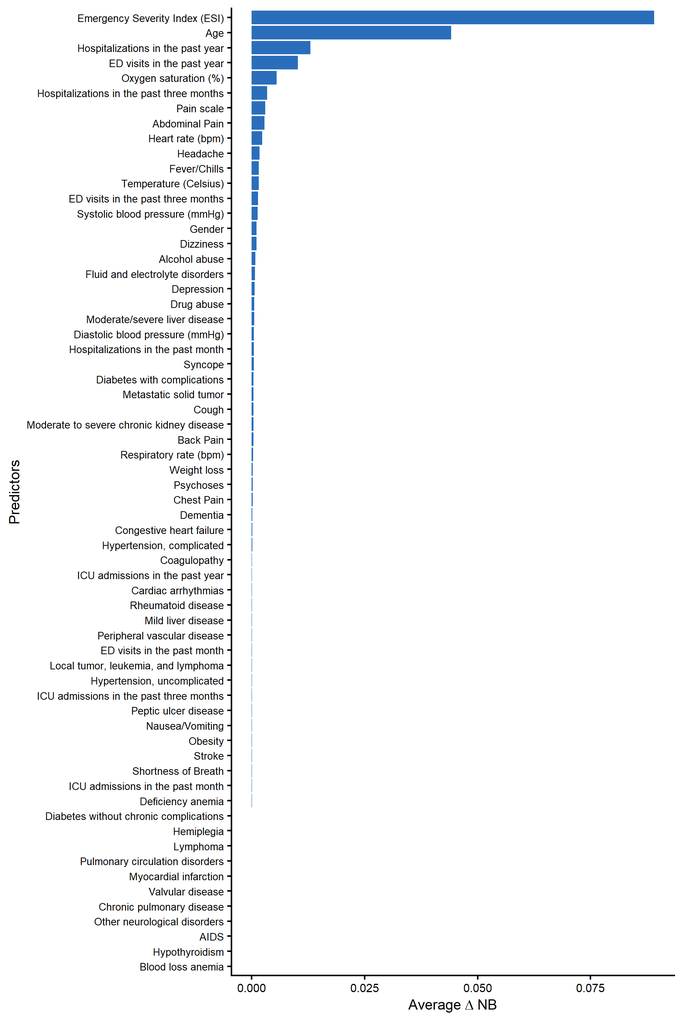

Figure 11: Figure S5 (left). Variable importance according to NB for the MIMIC-ED case study using BE NBvarsel 1.

```r
groupwise_all_5to7 <- groupwise_5to7$all_models
vif_MIMIC_5to7 <- VIF_plot(groupwise_all_5to7, data_dict = data_dict_mimic)
p_s5_left <- vif_MIMIC_5to7$plot + theme(text = element_text(size = 9), axis.text.y = element_text(size = 6.5))
p_s5_left
p_s5_left |>
  ggsave(filename = file.path(path_figures_paper, "Figure_S5_left.svg"), width = 4.5, height = 9, dpi = 300)
p_s5_left |>
  ggsave(filename = file.path(path_figures_paper, "Figure_S5_left.pdf"), width = 4.5, height = 9, dpi = 300)
```

### 5.4.3 NB Variable selection 50 to 70% (BE NBvarsel 2)

**Run BE NBvarsel selection for MIMIC-IV ED with group size 2 and 50%-70% thresholds**

```r
start_time <- Sys.time()
groupwise_5to7_2 <- nb_varsel(
  data = train_data[,c(vars_mimic,outcome)],
  outcome_var = outcome,
  costs = 0,
  thresholds =seq(0.5,0.7, by = 0.01),
  include_interactions = F,
  cv_folds = 5,
  mode = "groupwise",
  allow_parallel = T,
  permutation = TRUE,
  splines = F,
  group_size = 2,
  seed = 111
)
saveRDS(groupwise_5to7_2, file = file.path(path_processdata , "groupwise_5to7_2_results_mimic.RDS"))
end_time <- Sys.time()
run_duration <- end_time - start_time
#  1.39806 days
```

**Plot variable importance for MIMIC-IV ED BE NBvarsel selection with group size 2**

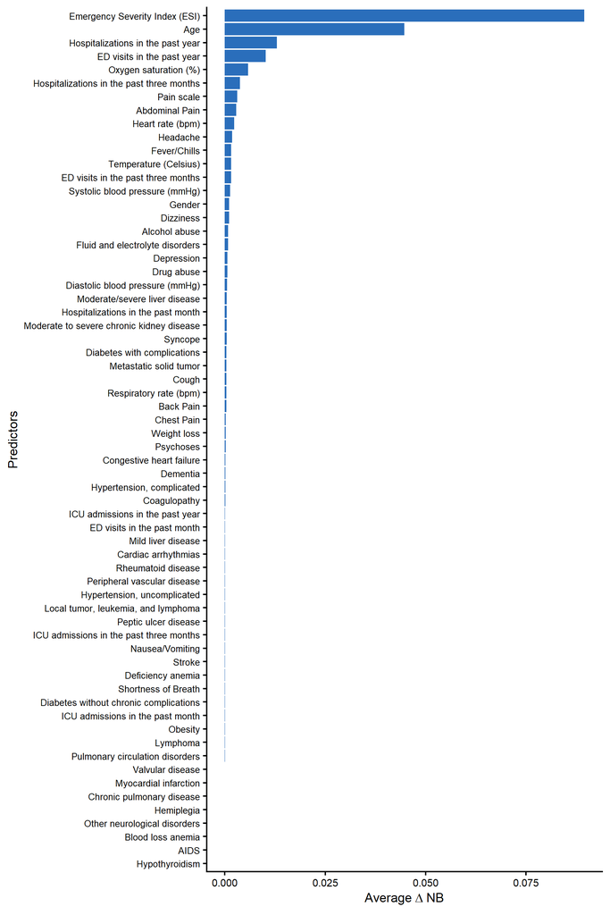

Figure 12: Figure S5 (right). Variable importance according to NB for the MIMIC-ED case study using BE NBvarsel 2.

```r
groupwise_all_5to7_2 <- groupwise_5to7_2$all_models
vif_MIMIC_5to7_2 <- VIF_plot(groupwise_all_5to7_2, data_dict = data_dict_mimic)
p_s5_right <- vif_MIMIC_5to7_2$plot + theme(text = element_text(size = 9), axis.text.y = element_text(size = 6.5))
p_s5_right
p_s5_right |>
  ggsave(filename = file.path(path_figures_paper, "Figure_S5_right.svg"), width = 4.5, height = 9, dpi = 300)
p_s5_right |>
  ggsave(filename = file.path(path_figures_paper, "Figure_S5_right.pdf"), width = 4.5, height = 9, dpi = 300)
Fig_S5 <- ggarrange(
  p_s5_left,
  p_s5_right,
  ncol = 2, nrow = 1
)
ggsave(Fig_S5, filename = file.path(path_figures_paper, "Figure_S5.svg"), width = 8.5, height = 9, dpi = 300)
ggsave(Fig_S5, filename = file.path(path_figures_paper, "Figure_S5.pdf"), width = 8.5, height = 9, dpi = 300)
```

## 5.5 Removed variables

**Identify variables removed by the two BE NBvarsel models, BE, and LASSO**

```r
preds_groupwise1_5to7 <- unlist(str_split(groupwise_5to7$best_model_stats$Model,
                                     pattern = ",", simplify = TRUE)) |> str_trim()

preds_groupwise2_5to7 <- unlist(str_split(groupwise_5to7_2$best_model_stats$Model
                                     ,pattern = ",", simplify = TRUE)) |> str_trim()
```

Removed variables from BE NBvarsel selection (Group size 1, thresholds 50 to 70%): **N = 15**; n_ed_30d, n_icu_30d, n_icu_90d, cci_MI, cci_Pulmonary, cci_Liver1, cci_DM1, cci_Paralysis, cci_HIV, eci_Valvular, eci_HTN1, eci_Hypothyroid, eci_Lymphoma, eci_Obesity, eci_BloodLoss

Removed variables from BE NBvarsel selection (Group size 2, thresholds 50 to 70%): **N = 16**; n_ed_30d, n_icu_30d, n_icu_90d, cci_MI, cci_Stroke, cci_Pulmonary, cci_Liver1, cci_Paralysis, cci_HIV, eci_Valvular, eci_PHTN, eci_HTN1, eci_Hypothyroid, eci_Obesity, eci_BloodLoss, eci_Anemia

Removed variables from BE model: **N = 16**; n_ed_30d, n_icu_30d, n_icu_90d, chiefcom_shortness_of_breath, cci_MI, cci_Pulmonary, cci_DM1, cci_Cancer1, cci_HIV, eci_Valvular, eci_PHTN, eci_HTN1, eci_NeuroOther, eci_Hypothyroid, eci_Lymphoma, eci_BloodLoss

Removed variables from LASSO model: **N = 13**; n_icu_30d, chiefcom_chest_pain, chiefcom_abdominal_pain, chiefcom_headache, chiefcom_shortness_of_breath, chiefcom_back_pain, chiefcom_cough, chiefcom_nausea_vomiting, chiefcom_fever_chills, chiefcom_syncope, chiefcom_dizziness, cci_Pulmonary, eci_PHTN

## 5.6 Performance

**Fit logistic models using the two selected MIMIC-IV ED predictor sets**

```r
groupwise1_5to7_model_fmla <-as.formula(paste0(outcome, "~",  stringr::str_replace_all(groupwise_5to7$best_model_stats$Model,",","+")))

model1_5to7 <- glm(formula = groupwise1_5to7_model_fmla, data = train_data, family = binomial())

preds_1_5to7 <- predict(model1_5to7, newdata = test_data, type = "response")

test_data$preds_groupwise1_5to7 <- preds_1_5to7

groupwise2_5to7_model_fmla <-as.formula(paste0(outcome, "~",  stringr::str_replace_all(groupwise_5to7_2$best_model_stats$Model,",","+")))

model2_5to7 <- glm(formula = groupwise2_5to7_model_fmla, data = train_data, family = binomial())

preds_2_5to7 <- predict(model2_5to7, newdata = test_data, type = "response")

test_data$preds_groupwise2_5to7 <- preds_2_5to7
```

### 5.6.1 Discrimination

**Calculate AUC values for the two BE NBvarsel MIMIC-IV ED models**

```r
auc_groupwise1_5to7 <- pROC::roc(test_data[[outcome]], test_data$preds_groupwise1_5to7, quiet = TRUE)$auc
auc_groupwise2_5to7 <- pROC::roc(test_data[[outcome]], test_data$preds_groupwise2_5to7, quiet = TRUE)$auc
```

AUC for BE NBvarsel selection with group size 1 was 0.812, for BE NBvarsel selection with group size 2 was 0.812, for the baseline model was 0.812, for the BE model was 0.812, and for the LASSO model was 0.812.

### 5.6.2 Calibration

**Plot calibration curves for the two BE NBvarsel models and comparison models**

```r
cal_groupwise1_5to7 <- valProbggplot(y = y_calib, p = test_data$preds_groupwise1_5to7, smooth = "rcs")
cal_groupwise2_5to7 <- valProbggplot(y = y_calib, p = test_data$preds_groupwise2_5to7, smooth = "rcs")

model_linetypes <- c(
  "BE"            = "dotdash",
  "BE NBvarsel 1" = "solid",
  "BE NBvarsel 2" = "dashed",
  "Full model"    = "solid",
  "LASSO"         = "twodash"
)

calibration_combined <- ggplot() +
  geom_line(data = calibration$CalibrationCurves$RCS, aes(x = x, y = xbeta, color = "Full model", linetype = "Full model"), linewidth = 1.10, alpha = 0.70) +
  geom_line(data = calibration_lasso$CalibrationCurves$RCS, aes(x = x, y = xbeta, color = "LASSO", linetype = "LASSO"), linewidth = 0.95, alpha = 0.85) +
  geom_line(data = calibration_bw$CalibrationCurves$RCS, aes(x = x, y = xbeta, color = "BE", linetype = "BE"), linewidth = 0.95, alpha = 0.85) +
  geom_line(data = cal_groupwise1_5to7$CalibrationCurves$RCS, aes(x = x, y = xbeta, color = "BE NBvarsel 1", linetype = "BE NBvarsel 1"), linewidth = 1.25, alpha = 0.85) +
  geom_line(data = cal_groupwise2_5to7$CalibrationCurves$RCS, aes(x = x, y = xbeta, color = "BE NBvarsel 2", linetype = "BE NBvarsel 2"), linewidth = 1.00, alpha = 0.95) +
  theme_classic(base_size = 12) +
  labs(x = "Estimated Probability", y = "Observed Proportion", color = "Model", linetype = "Model") +
  geom_abline(intercept = 0, slope = 1, linetype = "dashed", color = "gray60") +
  scale_color_manual(values = global_model_colors, breaks = names(model_linetypes), name = "Model") +
  scale_linetype_manual(values = model_linetypes, breaks = names(model_linetypes), name = "Model") +
  guides(
    color = guide_legend(
      title = "Model",
      override.aes = list(
        linewidth = c(0.95, 1.25, 1.00, 1.10, 0.95),
        alpha = c(0.85, 0.85, 0.95, 0.70, 0.85)
      )
    )
  ) +
  theme(legend.position = c(0.85, 0.25), legend.text = element_text(size = 10), text = element_text(size = 12))
calibration_combined |> ggsave(path = path_figures_paper, filename = "Figure_S6.svg", width = 5.5, height = 5.5)
calibration_combined |> ggsave(path = path_figures_paper, filename = "Figure_S6.pdf", width = 5.5, height = 5.5)
calibration_combined |> plotly::ggplotly() |> plotly::layout(hovermode = "x")
```

[interactive chart not shown]

Figure 13: Figure S6. Calibration plot for the MIMIC-ED case study. Distinct linetypes, line widths, and transparencies are used to differentiate overlapping models (e.g., solid line for BE NBvarsel 1 and dashed line for BE NBvarsel 2). Histograms of predicted risks are available in the report.

**Compare predicted probabilities from the two BE NBvarsel models with the baseline model**

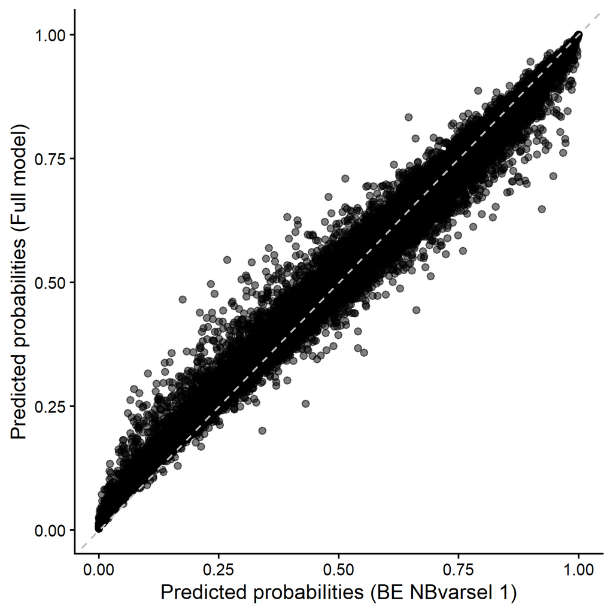

Figure 14: Online Only Figure 3. Comparison of predicted probabilities between the BE NBvarsel selection models and the full model in the MIMIC-ED case study.

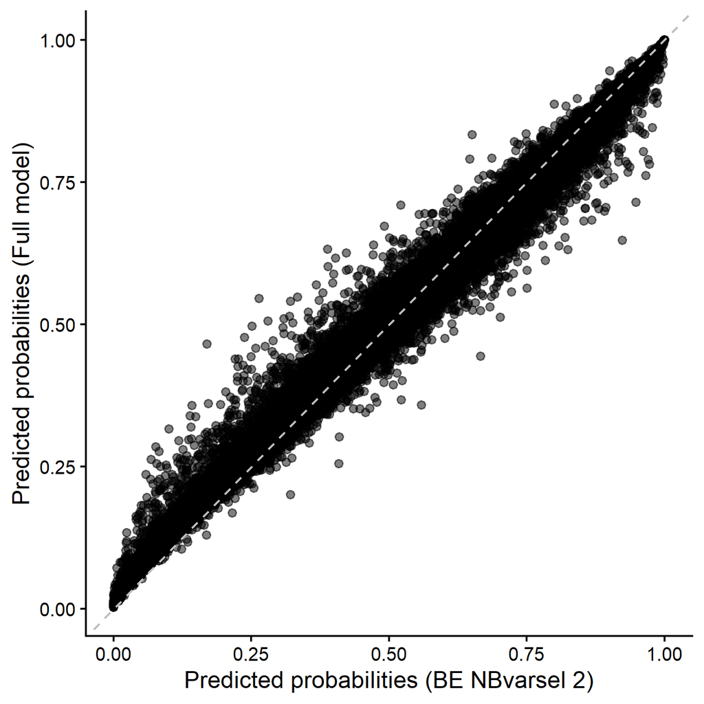

Figure 15: Online Only Figure 3. Comparison of predicted probabilities between the BE NBvarsel selection models and the full model in the MIMIC-ED case study.

```r
# Scatterplot one vs the other

scatter_mimic_1 <- ggplot(data = test_data, aes(x = preds_1_5to7, y = preds_baseline)) +
  geom_point(alpha = 0.5) +
  theme_classic(base_size = 12) +
  labs(x = "Predicted probabilities (BE NBvarsel 1)", y = "Predicted probabilities (Full model)") +
  geom_abline(intercept = 0, slope = 1, linetype = "dashed", color = "gray")
scatter_mimic_2 <- ggplot(data = test_data, aes(x = preds_2_5to7, y = preds_baseline)) +
  geom_point(alpha = 0.5) +
  theme_classic(base_size = 12) +
  labs(x = "Predicted probabilities (BE NBvarsel 2)", y = "Predicted probabilities (Full model)") +
  geom_abline(intercept = 0, slope = 1, linetype = "dashed", color = "gray")
scatter_mimic_combined <- ggarrange(scatter_mimic_1, scatter_mimic_2, ncol = 2, nrow = 1)
ggsave(scatter_mimic_combined, filename = file.path(path_figures_paper, "Online_Only_Figure_3.svg"), width = 10, height = 5, dpi = 300)
scatter_mimic_1
scatter_mimic_2
```

**Plot predicted-probability distributions by hospitalization status and model**

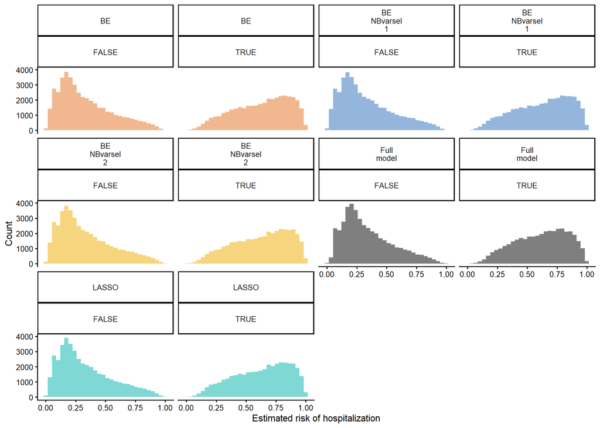

Figure 16: Online Only Figure 4. Distribution of predicted probabilities for all models in the MIMIC-ED case study.

```r
test_data_long <- test_data %>%
  select(outcome_hospitalization,preds_groupwise1_5to7, preds_groupwise2_5to7, preds_baseline, preds_bw, preds_lasso) |>
  pivot_longer(cols = starts_with("preds_"), names_to = "Model", values_to = "Predicted_Probability") %>%
  mutate(Model = recode(Model,
    preds_groupwise1_5to7 = "BE NBvarsel 1",
    preds_groupwise2_5to7 = "BE NBvarsel 2",
    preds_baseline   = "Full model",
    preds_bw         = "BE",
    preds_lasso      = "LASSO"
  ))

plot_dist_MIMIC <- ggplot(test_data_long, aes(x = Predicted_Probability, fill = Model)) +
  geom_histogram(position = "identity", alpha = 0.5, bins = 30) +
  facet_wrap(Model ~outcome_hospitalization, ncol = 4, labeller = label_wrap_gen(width = 4)) +
  theme_classic(base_size = 8) +
  labs(x = "Estimated risk of hospitalization", y = "Count") +
  scale_fill_manual(values = global_model_colors,aesthetics = c("fill", "color"), name = "Model") +
  theme(legend.position = "none")
plot_dist_MIMIC |> ggsave(filename = "Online_Only_Figure_4.svg", path = path_figures_paper, width = 6.5, height = 4.5, dpi = 300)
plot_dist_MIMIC |> ggsave(filename = "Online_Only_Figure_4.pdf", path = path_figures_paper, width = 6.5, height = 4.5, dpi = 300)
plot_dist_MIMIC
```

### 5.6.3 Clinical utility

**Calculate and plot MIMIC-IV ED decision curves for all comparison models**

```r
library(dcurves)
dca_mimic <- dca(
  formula = as.formula(paste0(outcome, "~ preds_groupwise1_5to7  + preds_groupwise2_5to7 + preds_baseline + preds_bw + preds_lasso")),
  data = test_data,
  thresholds = seq(0, 0.99, by = 0.05),
  label = list(
    preds_groupwise1_5to7 = "BE NBvarsel 1",
    preds_groupwise2_5to7 = "BE NBvarsel 2",
    preds_baseline   = "Full model",
    preds_bw         = "BE",
    preds_lasso      = "LASSO"
  )
)

dca_mimic_plot <- dca_mimic |> plot(smooth = TRUE) + theme_classic(base_size = 12) + scale_color_manual(values = global_model_colors, name = "Strategy")+ theme(legend.position = "top")

plot_dca <- as_tibble(dca_mimic) %>%
  dplyr::filter(!is.na(net_benefit)) %>%
  ggplot(aes(x = threshold, y = net_benefit, color = label, linetype = label)) +
  stat_smooth(method = "loess", se = FALSE, formula = "y ~ x",
    span = 0.2, lwd = 0.7) + theme_classic(base_size = 8) + scale_color_manual(values = global_model_colors,aesthetics = c("fill", "color"), name = "Strategy")+ theme(legend.position = "top") +
  labs(x = "Threshold Probability", y = "Net Benefit", color = "")+
  scale_linetype_manual(values = c("solid", "solid", "solid","solid", "solid", "solid","solid"),name = "Strategy") +
  theme(legend.spacing.y = unit(0.05, "cm"),legend.key.height = unit(0.3, "cm"))+ coord_cartesian(xlim = c(0, 1), ylim = c(0,0.5))+ guides(color = guide_legend(nrow = 2), fill = guide_legend(nrow = 2))

plot_dca |> ggsave(filename = "Online_Only_Figure_5.svg", path = path_figures_paper, width = 4, height = 4)
plot_dca |> ggsave(filename = "Online_Only_Figure_5.pdf", path = path_figures_paper, width = 4, height = 4)
dca_mimic_plot |> plotly::ggplotly() |>  plotly::layout(hovermode = "x")
```

[interactive chart not shown]

Figure 17: Online Only Figure 5. Decision curve analysis comparing the net benefit of the BE NBvarsel selection models and the baseline model in the MIMIC-ED case study. NB: Net Benefit.

### 5.6.4 Performance summary MIMIC

**Create a decision-threshold table of net benefit for the MIMIC-IV ED models**

```r
tbl_mimic <- dca_mimic_plot$data |>
  pivot_wider(names_from = label, values_from = net_benefit, id_cols = threshold) |>
  rowwise() |>
  mutate(
    # Added na.rm = TRUE just in case your DCA data has missing net benefits at certain thresholds
    max_val = max(c_across(c(`Treat All`, `BE NBvarsel 1`, `BE NBvarsel 2`, `Full model`,`BE`,`LASSO`)), na.rm = TRUE)
  ) |>
  ungroup() |>
  gt() |>
  fmt_number(
    columns = c(`Treat All`, `BE NBvarsel 1`, `BE NBvarsel 2`, `Full model`,`BE`,`LASSO`),
    decimals = 6
  ) |>

  # --- Apply the Green Highlights ---

  tab_style(
    style = cell_fill(color = "lightgreen"),
    locations = cells_body(columns = `Treat All`, rows = `Treat All` == max_val)
  ) |>
  tab_style(
    style = cell_fill(color = "lightgreen"),
    locations = cells_body(columns = `BE NBvarsel 1`, rows = `BE NBvarsel 1` == max_val)
  ) |>
  tab_style(
    style = cell_fill(color = "lightgreen"),
    locations = cells_body(columns = `BE NBvarsel 2`, rows = `BE NBvarsel 2` == max_val)
  ) |>
  tab_style(
    style = cell_fill(color = "lightgreen"),
    locations = cells_body(columns = `Full model`, rows = `Full model` == max_val)
  ) |>
    tab_style(
    style = cell_fill(color = "lightgreen"),
    locations = cells_body(columns = `BE`, rows = `BE` == max_val)
  ) |>
    tab_style(
    style = cell_fill(color = "lightgreen"),
    locations = cells_body(columns = `LASSO`, rows = `LASSO` == max_val)
  ) |>

  # Hide the helper column
  cols_hide(columns = max_val)
tbl_mimic
tbl_mimic |> tab_caption("Table 3. Net benefit performance in test data for MIMIC-ED comparison. Green cell indicates the best approach in terms of Net Benefit.") |> force_gtsave(filename = "Table_3.docx")
```

Table 10: Table 3. Net benefit performance in test data for MIMIC-ED comparison. Green cell indicates the best approach in terms of Net Benefit.

| threshold | Treat All | Treat None | BE NBvarsel 1 | BE NBvarsel 2 | Full model | BE | LASSO |
| --- | --- | --- | --- | --- | --- | --- | --- |
| 0.00 | 0.474230 | 0 | 0.474230 | 0.474230 | 0.474230 | 0.474230 | 0.474230 |
| 0.05 | 0.446558 | 0 | 0.446994 | 0.446979 | 0.446701 | 0.446959 | 0.446993 |
| 0.10 | 0.415811 | 0 | 0.419875 | 0.419827 | 0.419434 | 0.419859 | 0.419911 |
| 0.15 | 0.381447 | 0 | 0.393107 | 0.393126 | 0.391698 | 0.393181 | 0.392990 |
| 0.20 | 0.342788 | 0 | 0.368196 | 0.368220 | 0.366575 | 0.368273 | 0.368199 |
| 0.25 | 0.298973 | 0 | 0.343548 | 0.343496 | 0.342252 | 0.343464 | 0.343608 |
| 0.30 | 0.248900 | 0 | 0.318094 | 0.318060 | 0.318014 | 0.318135 | 0.318060 |
| 0.35 | 0.191123 | 0 | 0.291783 | 0.291626 | 0.291323 | 0.291616 | 0.291644 |
| 0.40 | 0.123717 | 0 | 0.264123 | 0.263908 | 0.263816 | 0.264183 | 0.263959 |
| 0.45 | 0.044055 | 0 | 0.236210 | 0.236240 | 0.235611 | 0.236352 | 0.236180 |
| 0.50 | −0.051540 | 0 | 0.210083 | 0.209904 | 0.208504 | 0.209964 | 0.209760 |
| 0.55 | −0.168378 | 0 | 0.181922 | 0.181573 | 0.179455 | 0.182166 | 0.181831 |
| 0.60 | −0.314425 | 0 | 0.154375 | 0.154303 | 0.151390 | 0.154441 | 0.153747 |
| 0.65 | −0.502200 | 0 | 0.126489 | 0.126570 | 0.124094 | 0.126359 | 0.126561 |
| 0.70 | −0.752567 | 0 | 0.096266 | 0.096174 | 0.095429 | 0.096330 | 0.096286 |
| 0.75 | −1.103080 | 0 | 0.069075 | 0.069027 | 0.067508 | 0.068357 | 0.068226 |
| 0.80 | −1.628850 | 0 | 0.041445 | 0.041277 | 0.040344 | 0.041553 | 0.041576 |
| 0.85 | −2.505133 | 0 | 0.016626 | 0.017204 | 0.019321 | 0.017511 | 0.017383 |
| 0.90 | −4.257700 | 0 | 0.002787 | 0.001531 | 0.006495 | 0.001208 | 0.002476 |
| 0.95 | −9.515400 | 0 | −0.006339 | −0.004904 | 0.000167 | −0.006327 | −0.005418 |

**Calculate and tabulate MIMIC-IV ED discrimination and calibration metrics**

```r
OE_groupwise1_5to7 <- sum(test_data[[outcome]])/sum(test_data$preds_groupwise1_5to7)
OE_groupwise2_5to7 <- sum(test_data[[outcome]])/sum(test_data$preds_groupwise2_5to7)
OE_BE <- sum(test_data[[outcome]])/sum(test_data$preds_bw)
OE_lasso <- sum(test_data[[outcome]])/sum(test_data$preds_lasso)
delta_OE_groupwise1_5to7 <- abs(1- sum(test_data[[outcome]])/sum(test_data$preds_baseline)) - abs(1-OE_groupwise1_5to7)
delta_OE_groupwise2_5to7 <- abs(1- sum(test_data[[outcome]])/sum(test_data$preds_baseline)) - abs(1-OE_groupwise2_5to7)
delta_OE_BE <- abs(1- sum(test_data[[outcome]])/sum(test_data$preds_baseline)) - abs(1-OE_BE)
delta_OE_lasso <- abs(1- sum(test_data[[outcome]])/sum(test_data$preds_baseline)) - abs(1-OE_lasso)
brier_groupwise1_5to7 <- mean((test_data[[outcome]] - test_data$preds_groupwise1_5to7)^2)
brier_groupwise2_5to7 <- mean((test_data[[outcome]] -test_data$preds_groupwise2_5to7)^2)
brier_baseline <- mean((test_data[[outcome]] - test_data$preds_baseline)^2)
brier_BE <- mean((test_data[[outcome]] - test_data$preds_bw)^2)
brier_lasso <- mean((test_data[[outcome]] - test_data$preds_lasso)^2)
delta_brier_groupwise1_5to7 <- brier_baseline - brier_groupwise1_5to7
delta_brier_groupwise2_5to7 <- brier_baseline - brier_groupwise2_5to7
delta_brier_BE <- brier_baseline - brier_BE
delta_brier_lasso <- brier_baseline - brier_lasso

nb_groupwise1 <- dca_mimic_plot$data |>  dplyr::filter(threshold >= 0.5 & threshold <= 0.7)  |> filter(label == "BE NBvarsel 1") |> pull(net_benefit) |> mean()
nb_groupwise2 <- dca_mimic_plot$data |>  dplyr::filter(threshold >= 0.5 & threshold <= 0.7)  |> filter(label == "BE NBvarsel 2") |> pull(net_benefit) |> mean()
nb_baseline <- dca_mimic_plot$data |>  dplyr::filter(threshold >= 0.5 & threshold <= 0.7)  |> filter(label == "Full model") |> pull(net_benefit) |> mean()
nb_BE <- dca_mimic_plot$data |>  dplyr::filter(threshold >= 0.5 & threshold <= 0.7)  |> filter(label == "BE") |> pull(net_benefit) |> mean()
nb_lasso <- dca_mimic_plot$data |>  dplyr::filter(threshold >= 0.5 & threshold <= 0.7)  |> filter(label == "LASSO") |> pull(net_benefit) |> mean()
delta_nb_groupwise1 <- nb_groupwise1 - nb_baseline
delta_nb_groupwise2 <- nb_groupwise2 - nb_baseline
delta_nb_BE <- nb_BE - nb_baseline
delta_nb_lasso <- nb_lasso - nb_baseline
smry_mimic_perf <- tibble(
  Model = c("BE NBvarsel 1", "BE NBvarsel 2", "Full model", "BE", "LASSO"),
  AUC = c(auc_groupwise1_5to7, auc_groupwise2_5to7, auc_ridge, auc_bw, auc_lasso),
  OE = c(OE_groupwise1_5to7, OE_groupwise2_5to7,  sum(test_data[[outcome]])/sum(test_data$preds_baseline), OE_BE, OE_lasso),
  Brier = c(brier_groupwise1_5to7, brier_groupwise2_5to7, brier_baseline, brier_BE, brier_lasso),
  Delta_AUC = c(auc_groupwise1_5to7 - auc_ridge, auc_groupwise2_5to7 - auc_ridge,0, auc_bw - auc_ridge, auc_lasso - auc_ridge),
  Delta_OE = c(delta_OE_groupwise1_5to7, delta_OE_groupwise2_5to7, 0,delta_OE_BE, delta_OE_lasso),
  Delta_Brier = c(delta_brier_groupwise1_5to7, delta_brier_groupwise2_5to7,0, delta_brier_BE, delta_brier_lasso),
  NB = c(nb_groupwise1, nb_groupwise2, nb_baseline, nb_BE, nb_lasso),
  Delta_NB = c(delta_nb_groupwise1, delta_nb_groupwise2,0, delta_nb_BE, delta_nb_lasso)
)

smry_mimic_perf_gt <- smry_mimic_perf|>
  gt() |>
  fmt_number(columns = c(AUC,OE,Brier,Delta_AUC, Delta_OE, Delta_Brier,NB,Delta_NB), decimals = 4)
smry_mimic_perf_gt
smry_mimic_perf_gt |> tab_caption("Online Only Table 6. Performance metrics for the BE NBvarsel selection models and the baseline model. AUC: Area under the receiver operating characteristic curve. OE: Observed-to-expected ratio.") |> force_gtsave(filename = "Online_Only_Table_6.docx")
```

Table 11: Online Only Table 6. Performance metrics for the BE NBvarsel selection models and the baseline model. AUC: Area under the receiver operating characteristic curve. OE: Observed-to-expected ratio.

| Model | AUC | OE | Brier | Delta_AUC | Delta_OE | Delta_Brier | NB | Delta_NB |
| --- | --- | --- | --- | --- | --- | --- | --- | --- |
| BE NBvarsel 1 | 0.8124 | 1.0030 | 0.1771 | 0.0008 | 0.0001 | 0.0008 | 0.1682 | 0.0024 |
| BE NBvarsel 2 | 0.8124 | 1.0030 | 0.1771 | 0.0008 | 0.0001 | 0.0008 | 0.1681 | 0.0022 |
| Full model | 0.8116 | 1.0031 | 0.1779 | 0.0000 | 0.0000 | 0.0000 | 0.1659 | 0.0000 |
| BE | 0.8125 | 1.0031 | 0.1771 | 0.0009 | 0.0001 | 0.0009 | 0.1682 | 0.0024 |
| LASSO | 0.8124 | 1.0031 | 0.1771 | 0.0008 | 0.0001 | 0.0008 | 0.1680 | 0.0021 |

All approaches achieved similar AUCs (0.812) (Table 11). The most important predictors according to BE NBvarsel were acuity at triage (Emergency Severity Index), patient age, and prior ED visits and hospitalizations in the previous year (Figure 11, Figure 12), aligning with the top features reported by Xie et al. Calibration was slightly closer to the diagonal for the BE method and BE NBvarsel models, although they tended to overestimate high risks (>0.60) slightly more than the full model (Figure 13). The NB variable-selection models consistently showed slightly higher clinical utility across the decision-curve range (thresholds 0.05 to 0.75), except at very high thresholds (>= 0.85), where the full model showed higher utility (Table 10, Figure 17). The complete results are available in Table 11, and comparisons of individual predictions between the baseline and BE NBvarsel models are shown in Figure 14 and Figure 15.

# 6 DENTS (NTS bloodstream infection)

**ImportantNot reproducible section**

This section cannot be reproduced because the original data are not publicly available. The code is included here for transparency.

This case study uses prospective cohort data to predict the risk of non-typhoidal Salmonella (NTS) bloodstream infection in children under five, to guide the choice of empirical antibiotics ([Tack et al., 2025](https://pubmed.ncbi.nlm.nih.gov/32677939/)). The dataset contains clinical information collected prospectively from 2,327 paediatric hospital admissions (2,323 with complete data) for severe febrile illness at Kisantu District Hospital in the Democratic Republic of the Congo. We use the a priori clinical predictors proposed by Tack et al., applying their exact variable definitions and restricted cubic-spline transformations. The authors proposed this specific set of predictors based on a systematic literature review to ensure clinical relevance and avoid data-driven artefacts; therefore, we followed their guidelines when defining the variables. They proposed 11 predictors for models of antibiotic triage and developed a simplified clinical scoring system alongside them, but we focus on their main multivariable logistic-regression (LR) model.

In their work, variables were selected using a double backward-elimination process, and the final model was fitted using Firth’s correction. We compare their approach with the proposed net-benefit variable-selection method, which includes splines for continuous predictors, and fit the final model using Firth’s correction as well. In our algorithm, continuous predictors were either represented using splines or removed. The authors proposed a reasonable threshold range of 20% to 50%; we therefore used this range in the variable-selection procedure.

## 6.1 Dataset descriptives

**Create descriptive statistics for the DENTS case study dataset**

```r
vars_dents <- c("nts",
                "age_m_calc",
          "season",
          "ldurfev",
          "mh_diarrh",
          "malnutf",
          "resp_man",
          "distress",
          "hepaspl",
          "malarf",
          "hb_corr",
          "n_antibiotics"
)

data_dict_dents <- c(
  "nts"           = "NTS Status",
  "age_m_calc"    = "Age at admission (months)",
  "season"        = "Season of admission",
  "ldurfev"       = "Fever duration on admission (log days)",
  "durfev"        = "Fever duration on admission (days)",
  "dur_fev"        = "Fever duration on admission (days)",
  "mh_diarrh"     = "Diarrhea",
  "malnutf"       = "Nutritional status",
  "resp_man"      = "Respiratory rate (breaths/min)",
  "distress"      = "Respiratory distress",
  "hepaspl"       = "Hepato- or splenomegaly",
  "malarf"        = "Malaria status",
  "hb_corr"       = "Hemoglobin (g/dl)",
  "n_antibiotics" = "Antibiotics"
)
rename_dict_dents <- stats::setNames(names(data_dict_dents), data_dict_dents)
#Rename columns


# dents_cc is a data frame containing the DENTS case study data

dents_descriptive <- dents_cc |>
  select(all_of(vars_dents),dur_fev,-ldurfev) |>
  dplyr::rename(dplyr::any_of(rename_dict_dents)) |>
  tbl_summary(by = `NTS Status`,missing_text = "Missing",  statistic = list(all_continuous() ~
  "{median} ({p25}, {p75})[{min}-{max}]", all_categorical() ~ "{n} ({p}%)"), missing_stat = "{N_miss} ({p_miss}%)") |>  modify_header(
    all_stat_cols() ~ "**{level}**\nN = {n} ({style_number(p * 100, digits = 0)}%)"
  )
dents_descriptive
dents_descriptive |> modify_caption("Table S3. Descriptive statistics for the non-typhoidal Salmonella case study.") |> as_flex_table() |> save_as_docx(path = file.path(path_tables_paper, "Table_S3.docx"))
```

Table 12: Table S3. Descriptive statistics for the non-typhoidal Salmonella case study.

| **Characteristic** | **0** N = 2029 (87%)<sup>1</sup> | **1** N = 294 (13%)<sup>1</sup> |
| --- | --- | --- |
| Age at admission (months) | 19 (10, 33)[1-59] | 15 (10, 23)[1-58] |
| Season of admission | 1,416 (70%) | 245 (83%) |
| Diarrhea | 393 (19%) | 91 (31%) |
| Nutritional status |  |  |
| 0 | 1,657 (82%) | 196 (67%) |
| 1 | 225 (11%) | 54 (18%) |
| 2 | 147 (7.2%) | 44 (15%) |
| Respiratory rate (breaths/min) | 42 (36, 52)[6-108] | 48 (38, 59)[20-104] |
| Respiratory distress | 531 (26%) | 112 (38%) |
| Hepato- or splenomegaly | 658 (32%) | 144 (49%) |
| Malaria status |  |  |
| 0 | 322 (16%) | 61 (21%) |
| 1 | 318 (16%) | 148 (50%) |
| 2 | 1,389 (68%) | 85 (29%) |
| Hemoglobin (g/dl) | 7.70 (6.40, 9.30)[1.40-19.80] | 7.60 (6.30, 9.10)[2.70-17.60] |
| Antibiotics | 721 (36%) | 128 (44%) |
| Fever duration on admission (days) | 3 (2, 4)[0-40] | 4 (3, 6)[0-19] |

<sup>1</sup> Median (Q1, Q3)[Min-Max]; n (%)

## 6.2 Minimum sample size analysis - DENTS

**Calculate the required sample size for the DENTS case study**

```r
labs_full_dents <- NBvarsel:::get_term_labels(vars_dents[-1], data = dents_cc, n_knots = 3)
fmla_full_dents <- reformulate(termlabels = labs_full_dents, response = "nts")
model_full_dents <- lrm(fmla_full_dents, data = dents_cc)


sample_size_dents <- pmsampsize(type = "b", parameters =length(model_full_dents$coefficients), prevalence = mean(dents_cc$nts), cstat = 0.79, shrinkage = 0.9,  seed = 1)

sample_size_dents$results_table |>
  as.data.frame() |>
  gt(rownames_to_stub = TRUE) |>
  tab_stubhead(label = "Criteria") |>
  tab_header(title = "Sample Size Calculation for DENTS Case Study")
```

Table 13: Online Only Table 7. Minimum sample size calculation for the non-typhoidal Salmonella case study.

Sample Size Calculation for DENTS Case Study

| Criteria | Samp_size | Shrinkage | Parameter | CS_Rsq | Max_Rsq | Nag_Rsq | EPP |
| --- | --- | --- | --- | --- | --- | --- | --- |
| Criteria 1 | 1213 | 0.900 | 18 | 0.1242 | 0.532 | 0.233 | 8.53 |
| Criteria 2 | 625 | 0.824 | 18 | 0.1242 | 0.532 | 0.233 | 4.39 |
| Criteria 3 | 170 | 0.900 | 18 | 0.1242 | 0.532 | 0.233 | 1.20 |
| Final | 1213 | 0.900 | 18 | 0.1242 | 0.532 | 0.233 | 8.53 |

## 6.3 Exhaustive variable selection

**Run exhaustive variable selection for the DENTS case study**

```r
prevalence <- mean(dents_cc$nts)
grouped_costs <- list(
  # Group 1: Clinical History (Cheap)
  basic = list(cost = 0, vars = c("age_m_calc","season","ldurfev","mh_diarrh","malnutf","distress", "hb_corr", "n_antibiotics")),

  # Group 2: experience
  ## TT 7900 = 0.001
  ## TT 790 = 0.01
  experience = list(cost = prevalence*0.1,
            vars = c("resp_man",  "hepaspl"))

)

start_time <- Sys.time()
exhaustive_results_dents <- nb_varsel(
  data = dents_cc |>  select(vars_dents),
  outcome_var = "nts",
  # costs = grouped_costs,
  thresholds =seq(0.20,0.50, by = 0.01),
  include_interactions = F,
  cv_folds = 20,
  mode = "exhaustive",
  allow_parallel = T,
  permutation = TRUE,
  splines = T,
)

end_time <- Sys.time()
```

### 6.3.1 Visualization

**Plot variable importance for the DENTS case study**

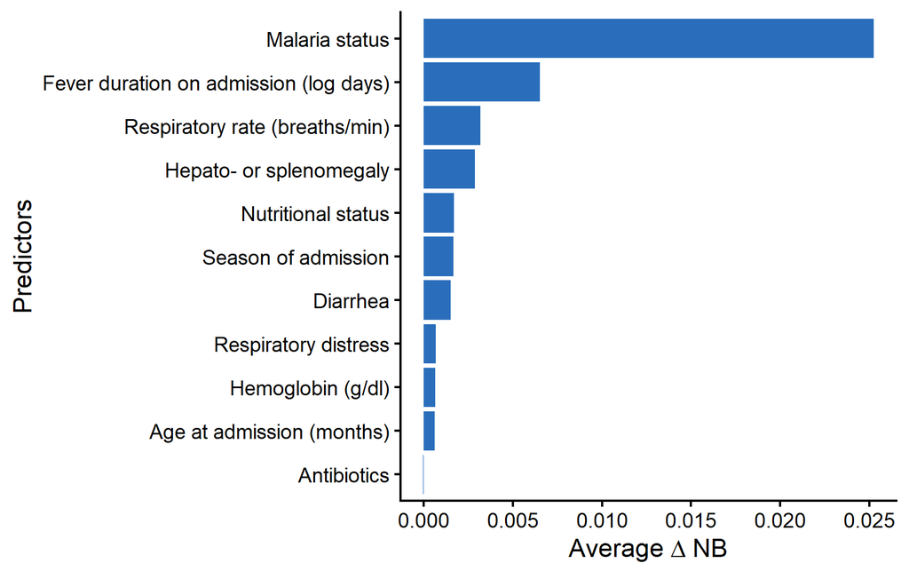

Figure 18: Figure S7. Variable importance of the non-typhoidal salmonella case study.

```r
VIF_dents <- VIF_plot(exhaustive_results_dents$all_models, data_dict = data_dict_dents)
VIF_dents$plot
VIF_dents$plot |> ggsave(path = path_figures_paper, filename = "Figure_S7.svg", width = 5.5, height = 3.5, dpi = 300)
VIF_dents$plot |> ggsave(path = path_figures_paper, filename = "Figure_S7.pdf", width = 5.5, height = 3.5, dpi = 300)
```

**Plot all-subset performance for the DENTS case study**

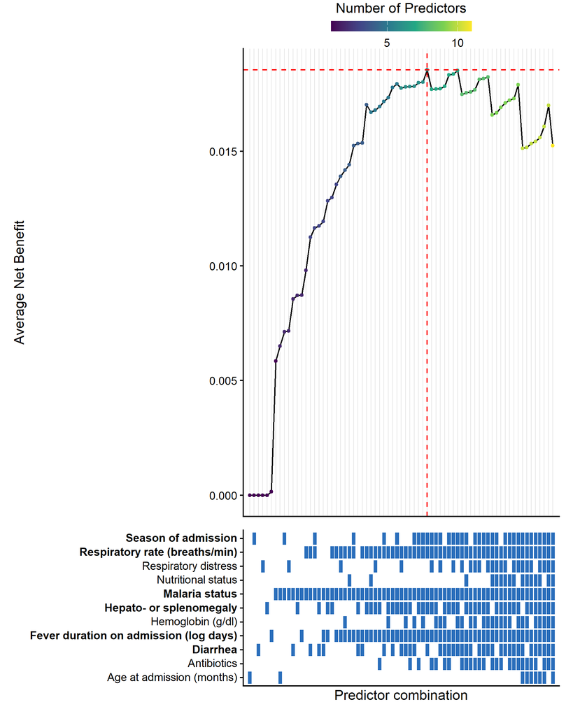

Figure 19: Figure S8. All subset plot for the non-typhoidal Salmonella case study. Bold predictors are included in the final model

```r
all_subset_dents <- all_subset_plot(exhaustive_results_dents$all_models, filter = 7, size_dot = 1, data_dict = data_dict_dents)
all_subset_dents
all_subset_dents |> ggsave(path = path_figures_paper, filename = "Figure_S8.svg", width = 6.4, height = 8, dpi = 300)
all_subset_dents |> ggsave(path = path_figures_paper, filename = "Figure_S8.pdf", width = 6.4, height = 8, dpi = 300)
```

## 6.4 Model fitting

### 6.4.1 NBvarsel model

**Fit the best net-benefit model for the DENTS case study**

```r
predictors <- exhaustive_results_dents$all_models |>
  arrange(-Avg_Net_Benefit) |> slice(1) |> pull(Model) |>
  stringr::str_split(pattern = ",", simplify = TRUE) |> as.vector() |> stringr::str_trim()
term_labs     <- NBvarsel:::get_term_labels(predictors, dents_cc, 3)
outcome_var <- "nts"
fmla     <- reformulate(termlabels = term_labs, response = outcome_var)
model_NB     <- logistf::logistf(formula = fmla, flic = TRUE, data = dents_cc)
estrisks_NB = predict(model_NB, newdata = dents_cc, type = "response")
estrisks_NB = as.data.frame(cbind(estrisks_NB,dents_cc$nts))
dents_cc$estrisks_NB = estrisks_NB$estrisks_NB
```

### 6.4.2 Published model

**Fit the published DENTS model with backward elimination and Firth correction**

```r
mod1 = lrm(nts ~ age_m_calc + season + ldurfev + mh_diarrh + malnutf + resp_man + distress + hepaspl + malarf +
             hb_corr + n_antibiotics + agercs + l2durrcs + resprcs + hbrcs, data=dents_cc)
mod2 = fastbw(mod1, rule="p", sls = 0.01, type="individual", force=c(1:13))
mod3 <- lrm(nts~., data=dents_cc[,c("nts",mod2$names.kept)])
mod4 = fastbw(mod3, rule="p", sls = 0.01, type="individual")

# THE FINAL model
mod5 = logistf::logistf(nts ~ ., flic=TRUE, data=dents_cc[,c("nts",mod4$names.kept)])


# 12. Estimated Risks for Final Model ----
estrisks = predict(mod5, newdata = dents_cc, type="response")
estrisks = as.data.frame(cbind(estrisks,dents_cc$nts))
dents_cc$estrisks = estrisks$estrisk
```

### 6.4.3 Backward elimination and LASSO

**Fit backward-elimination and LASSO comparison models for DENTS**

```r
term_labs_dents <- NBvarsel:::get_term_labels(vars_dents[-1], dents_cc, 3)
fmla_dents     <- reformulate(termlabels = term_labs_dents, response = "nts")

# Backward elimination
mod_be_dents <- lrm(fmla_dents, data = dents_cc)

mod_be_bw_dents <- fastbw(mod_be_dents)
term_labs_dents_be <- NBvarsel:::get_term_labels(mod_be_bw_dents$names.kept, dents_cc, 3)
fmla_dents_be   <- reformulate(term_labs_dents_be, response = "nts")

mod_be_final_dents <- logistf::logistf(fmla_dents_be, flic=TRUE, data=dents_cc)

# LASSO
x <- model.matrix(nts ~ ., data = dents_cc[,c(vars_dents)])[,-1]
y <- dents_cc$nts
set.seed(123)
cv_lasso_dents <- cv.glmnet(x, y, alpha = 1, family = "binomial", nfolds = 10)
# Predictions
dents_cc$preds_be <- predict(mod_be_final_dents, newdata = dents_cc, type = "response")
dents_cc$preds_lasso <- plogis(as.vector(predict(cv_lasso_dents, newx = x, s = "lambda.min")))
```

## 6.5 Removed variables

**Identify variables removed by the exhaustive, published, backward-elimination, and LASSO models**

```r
preds_best_nb <- unlist(str_split(exhaustive_results_dents$best_model_stats$Model, pattern = ",", simplify = TRUE)) |> str_trim()
preds_published <- mod4$names.kept[!grepl("rcs", mod4$names.kept)]
preds_be <- mod_be_bw_dents$names.kept
coefs_lasso_dents <- coef(cv_lasso_dents, s = "lambda.min")
preds_lasso <- rownames(coefs_lasso_dents)[which(coefs_lasso_dents[, 1] != 0)][-1] |>
  stringr::str_replace_all(c("malnutf[12]" = "malnutf", "malarf[12]" = "malarf")) |>
  unique()
```

Removed variables:

- According to NB: age_m_calc, malnutf, distress, hb_corr, n_antibiotics
- According to published strategy: distress, n_antibiotics
- According to backward elimination (`fastbw()`): distress
- According to LASSO: distress

## 6.6 Performance - Apparent

### 6.6.1 Discrimination

**Calculate AUC values and compare DENTS model predictions**

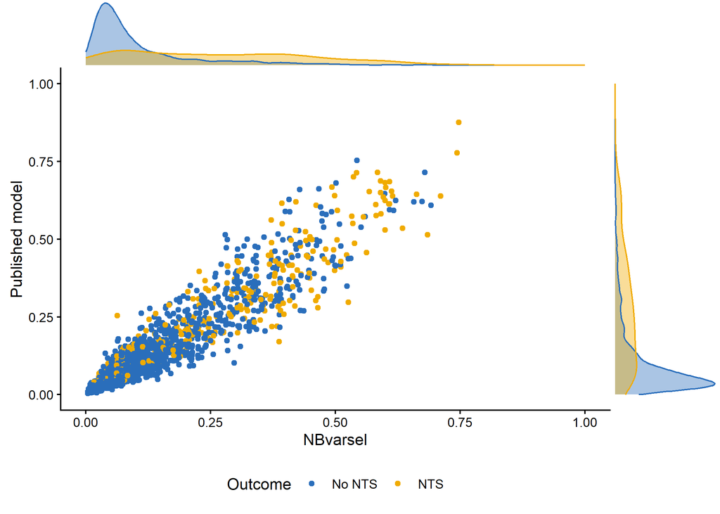

Figure 20: Figure S9. Distribution of individual risks for the model based on NB variable selection and the published model stratified by outcome. Plots in the margin depict densities per outcome. NTS: non-typhoidal Salmonella.

```r
auc_NB <- pROC::roc(dents_cc$nts, dents_cc$estrisks_NB, quiet = TRUE)$auc
auc_published <- pROC::roc(dents_cc$nts, dents_cc$estrisks, quiet = TRUE)$auc
auc_be <- pROC::roc(dents_cc$nts, dents_cc$preds_be, quiet = TRUE)$auc
auc_lasso <- pROC::roc(dents_cc$nts, dents_cc$preds_lasso, quiet = TRUE)$auc
# (sprintf(
#   "AUC  NB model: %.3f | Published model: %.3f",
#   auc_NB, auc_published
# ))
dents_cc$nts_plot <- factor(dents_cc$nts, levels = c(0, 1), labels = c("No NTS", "NTS"))

p <- ggplot(dents_cc, aes(x=estrisks_NB, y=estrisks, color = nts_plot)) +
  # annotate("rect",
  #          xmin = 0.20, xmax = 0.5,   # The x-axis range to shade
  #          ymin = -Inf, ymax = Inf,   # Spans the entire y-axis
  #          fill = "lightgray",        # Color of the shaded area
  #          alpha = 0.5)+
  geom_point() + theme(legend.position="none") + ylim(0,1)+xlim(0,1) +
  labs(x = "NBvarsel", y="Published model") + theme_classic()+ scale_color_bmj(name = "Outcome")+theme(legend.position = "bottom")
library(ggExtra)
p <- ggMarginal(
  p,
  type = "density",         # Can also be "histogram", "boxplot", or "violin"
  groupColour = TRUE,
  groupFill = TRUE,
  alpha = 0.4)
p
p |> ggsave(path = path_figures_paper, filename = "Figure_S9.svg", width = 5.5, height = 5.5)
p |> ggsave(path = path_figures_paper, filename = "Figure_S9.pdf", width = 5.5, height = 5.5)
```

AUC for the NBvarsel model is 0.787 and for the published model is 0.803. LASSO and backward elimination models obtained AUC of 0.804 and 0.804 respectively.

### 6.6.2 Calibration

**Plot LOESS calibration curves for the DENTS comparison models**

```r
cal_NB <- valProbggplot(y = dents_cc$nts, p = dents_cc$estrisks_NB, smooth = "loess")
cal_published <- valProbggplot(y = dents_cc$nts, p = dents_cc$estrisks, smooth = "loess")
cal_be <- valProbggplot(y = dents_cc$nts, p = dents_cc$preds_be, smooth = "loess")
cal_lasso <- valProbggplot(y = dents_cc$nts, p = dents_cc$preds_lasso, smooth = "loess")

model_linetypes <- c(
  "BE"            = "dotdash",
  "BE NBvarsel 1" = "solid",
  "BE NBvarsel 2" = "dashed",
  "Full model"    = "solid",
  "LASSO"         = "twodash"
)

calibration_combined <- ggplot() +
  # annotate("rect",
  #          xmin = 0.20, xmax = 0.5,   # The x-axis range to shade
  #          ymin = -Inf, ymax = Inf,   # Spans the entire y-axis
  #          fill = "lightgray",        # Color of the shaded area
  #          alpha = 0.5)+
  geom_line(data = cal_published$CalibrationCurves$FlexibleCalibration, aes(x = x, y = y, color = "Published"), lwd = 1) +
  geom_line(data = cal_NB$CalibrationCurves$FlexibleCalibration, aes(x = x, y = y, color = "NBvarsel"), lwd = 1) +
  geom_line(data = cal_be$CalibrationCurves$FlexibleCalibration, aes(x = x, y = y, color = "BE"), lwd = 1) +
  geom_line(data = cal_lasso$CalibrationCurves$FlexibleCalibration, aes(x = x, y = y, color = "LASSO"), lwd = 1) +
  theme_classic(base_size = 12) +
  labs(x = "Estimated Probability", y = "Observed Proportion", color = "Model") +
  geom_abline(intercept = 0, slope = 1, linetype = "dashed", color = "gray") +
  scale_color_manual(values = global_model_colors) +
  theme(legend.position = c(0.85, 0.25), legend.text = element_text(size = 10), text = element_text(size = 12))
```

**Plot estimated-risk distributions by NTS status and model**

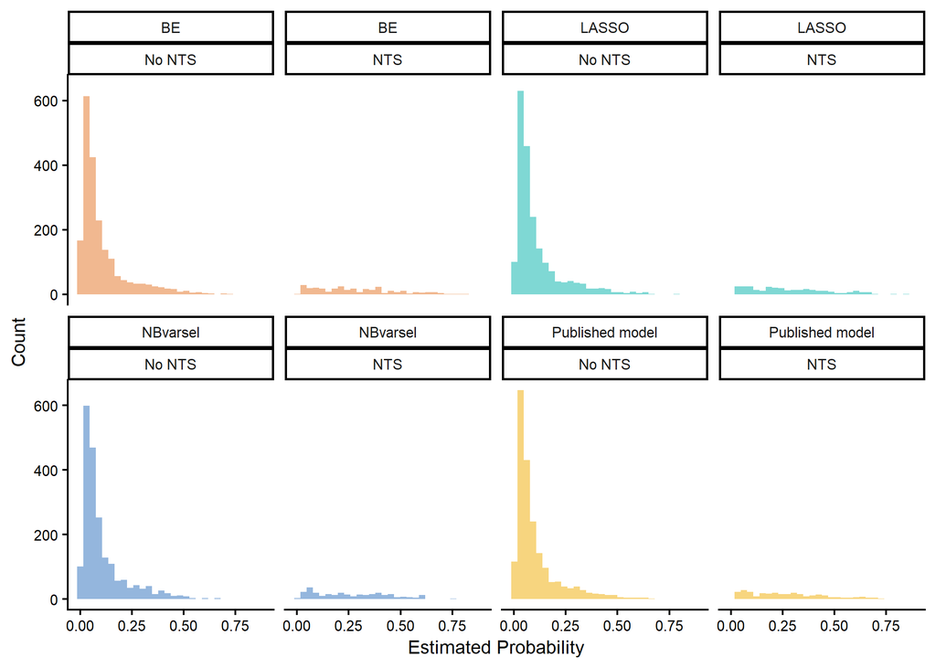

Figure 21: Online Only Figure 6. Distribution of estimated probabilities for the models in the non-typhoidal Salmonella case study.

```r
detnts_cc_long <- dents_cc |> select(starts_with("estrisks"), starts_with("preds"), nts) |> pivot_longer(cols = -nts, names_to = "Model", values_to = "Estimated_Probability") |> mutate(Model = case_when(
  str_detect(Model, "estrisks_NB") ~ "NBvarsel",
  str_detect(Model, "estrisks") ~ "Published model",
  str_detect(Model, "preds_be") ~ "BE",
  str_detect(Model, "preds_lasso") ~ "LASSO",
  TRUE ~ Model
))

hist_dents <- ggplot(detnts_cc_long, aes(x = Estimated_Probability, fill = Model)) +
  geom_histogram(position = "identity", alpha = 0.5, bins = 30,show.legend = F) +
  theme_classic(base_size = 12) +
  facet_wrap(Model ~ nts,ncol = 4, labeller = labeller(nts = c("0" = "No NTS", "1" = "NTS")))+
  labs(x = "Estimated Probability", y = "Count", fill = "Model") +
  scale_fill_manual(values = global_model_colors) +
  theme(legend.position = c(0.85, 0.25), legend.text = element_text(size = 10), text = element_text(size = 10))
hist_dents |> ggsave(path = path_figures_paper, filename = "Online_Only_Figure_6.svg", width = 6.5, height = 4.5, dpi = 300)
hist_dents |> ggsave(path = path_figures_paper, filename = "Online_Only_Figure_6.pdf", width = 6.5, height = 4.5, dpi = 300)
hist_dents
```

### 6.6.3 Clinical utility

**Plot DENTS calibration curves and decision curves for all comparison models**

```r
dca_dents <- dcurves::dca(nts ~ estrisks + estrisks_NB + preds_be + preds_lasso, data = dents_cc, thresholds = seq(0, 1, by = .05),
    label = list(
    estrisks = "Published model",
    estrisks_NB = "NBvarsel",
    preds_be = "BE",
    preds_lasso = "LASSO"
  )) |> plot(smooth = T) + theme_classic(base_size = 12) + scale_color_manual(values = global_model_colors, name = "Model")+ theme(legend.position = "top")

calibration_combined |> ggsave(path = path_figures_paper, filename = "Figure_S10.svg", width = 5.5, height = 5.5)
calibration_combined |> ggsave(path = path_figures_paper, filename = "Figure_S10.pdf", width = 5.5, height = 5.5)
dca_dents |> ggsave(path = path_figures_paper, filename = "Figure_S11.svg", width = 5.5, height = 5.5)
dca_dents |> ggsave(path = path_figures_paper, filename = "Figure_S11.pdf", width = 5.5, height = 5.5)
calibration_combined |> plotly::ggplotly() |> plotly::layout(hovermode = "x")
dca_dents |> plotly::ggplotly() |>  plotly::layout(hovermode = "x")
```

[interactive chart not shown]

Figure 22: Figure S10. Apparent calibration for the non-typhoidal Salmonella case study.

[interactive chart not shown]

Figure 23: Figure S11. Apparent decision curve analysis for the non-typhoidal Salmonella case study.

Individual risk estimates varied considerably between the published model and the model with variables removed (Figure 20). The AUC was slightly higher for the published model (0.80 vs. 0.79). Calibration was closer to the diagonal for the NB model at estimated risks below 45%, but the model tended to underestimate risk at higher estimated probabilities (Figure 22). The NB model had higher net benefit at decision thresholds from 25% to 55% (Figure 23).

## 6.7 Performance Bootstrap

**Run 1,000 bootstrap validations of DENTS discrimination, calibration, and net benefit**

```r
library(rsample)
library(dplyr)
library(stringr)
library(pROC)
library(rms)
library(logistf)
library(pbapply)

# --- Helper Functions for Metrics ---

full_x_matrix <- model.matrix(nts ~ ., data = dents_cc[, vars_dents])[, -1]
full_y_vector <- as.numeric(as.character(dents_cc$nts))
# 1. Calculate Net Benefit at a specific probability threshold
calc_dca_data <- function(preds, obs, pts) {
  N <- length(obs)
  obs_num <- as.numeric(as.character(obs))
  prev <- mean(obs_num) # Prevalence in this specific OOB sample

  # Vectorized calculation over all thresholds
  res <- lapply(pts, function(pt) {
    TP <- sum(preds >= pt & obs_num == 1)
    FP <- sum(preds >= pt & obs_num == 0)

    nb_model <- (TP / N) - (FP / N) * (pt / (1 - pt))
    nb_all <- prev - (1 - prev) * (pt / (1 - pt))

    data.frame(
      Threshold = pt,
      NB_Model = nb_model,
      NB_All = nb_all # Net benefit of Treat All (unfloored)
    )
  })

  return(do.call(rbind, res))
}

# 2. Bound predictions to avoid Inf in logit transformations for calibration
safe_logit <- function(p) {
  p <- pmin(pmax(p, 1e-5), 1 - 1e-5)
  qlogis(p)
}
clinical_pts <- seq(0.01, 0.99, by = 0.01)
# --- Initialization ---
set.seed(123)
n_boots <- 1000
boot_splits <- bootstraps(dents_cc, times = n_boots)


# Define your clinical threshold of interest for Net Benefit (e.g., 10%)

# --- Run the Bootstrap Loop ---
boot_results <- pblapply(1:n_boots, function(i) {

train_data <- analysis(boot_splits$splits[[i]])
  test_data  <- assessment(boot_splits$splits[[i]])

  obs_num <- as.numeric(as.character(test_data$nts))
  prev <- mean(obs_num) # Prevalence in the OOB sample

  # Initialize metrics as NA in case a model fails to converge
  auc_nb <- cal_slope_nb <- cal_int_nb <- brier_nb <- OE_nb <- NA
  auc_pub <- cal_slope_pub <- cal_int_pub <- brier_pub <- OE_pub <- NA
  auc_be <- cal_slope_be <- cal_int_be <- brier_be <- OE_be <- NA
  auc_lasso <- cal_slope_lasso <- cal_int_lasso <- brier_lasso <- OE_lasso <- NA

  preds_nb <- preds_pub <- preds_be_vars <- preds_lasso_vars <- NA

  dca_nb <- data.frame(Threshold = clinical_pts, NB_Model = NA, NB_All = prev - (1 - prev) * (clinical_pts / (1 - clinical_pts)))
  dca_pub <- dca_nb
  dca_be <- dca_nb
  dca_lasso <- dca_nb

  # ==========================================
  # A. Exhaustive Search (NB Model)
  # ==========================================
  nb_res <- tryCatch(nb_varsel(
    data = train_data |> select(all_of(vars_dents)),
    outcome_var = "nts",
    thresholds = seq(0.20, 0.50, by = 0.01),
    include_interactions = FALSE,
    cv_folds = 5,
    mode = "exhaustive",
    allow_parallel = TRUE,
    permutation = TRUE,
    splines = TRUE
  ), error = function(e) NULL)

  if(!is.null(nb_res)) {
      preds_nb <- nb_res$all_models |>
        arrange(-Avg_Net_Benefit) |> slice(1) |> pull(Model) |>
        str_split(pattern = ",", simplify = TRUE) |> as.vector() |> str_trim()

      term_labs <- NBvarsel:::get_term_labels(preds_nb, train_data, 3)
      fmla_nb   <- reformulate(termlabels = term_labs, response = "nts")
      model_NB <- tryCatch(logistf::logistf(formula = fmla_nb, flic = TRUE, data = train_data), error = function(e) NULL)

      if (!is.null(model_NB)) {
        estrisks_NB <- as.numeric(predict(model_NB, newdata = test_data, type = "response"))

        auc_nb <- pROC::roc(test_data$nts, estrisks_NB, quiet = TRUE)$auc
        dca_nb <- calc_dca_data(estrisks_NB, test_data$nts, clinical_pts)

        slope_mod <- tryCatch(glm(test_data$nts ~ safe_logit(estrisks_NB), family = binomial), error = function(e) NULL)
        int_mod   <- tryCatch(glm(test_data$nts ~ offset(safe_logit(estrisks_NB)), family = binomial), error = function(e) NULL)

        if(!is.null(slope_mod)) cal_slope_nb <- coef(slope_mod)[2]
        if(!is.null(int_mod)) cal_int_nb <- coef(int_mod)[1]

        brier_nb <- mean((obs_num - estrisks_NB)^2, na.rm = TRUE)
        OE_nb <- prev / mean(estrisks_NB, na.rm = TRUE)
      }
  }

  # ==========================================
  # B. Published Model
  # ==========================================
  mod1 <- tryCatch(lrm(nts ~ age_m_calc + season + ldurfev + mh_diarrh + malnutf + resp_man + distress + hepaspl + malarf +
                hb_corr + n_antibiotics + agercs + l2durrcs + resprcs + hbrcs, data=train_data), error=function(e) NULL)

  if(!is.null(mod1)) {
      mod2 <- tryCatch(fastbw(mod1, rule="p", sls = 0.01, type="individual", force=c(1:13)), error=function(e) NULL)
      if(!is.null(mod2)) {
          mod3_vars <- c("nts", mod2$names.kept)
          mod3 <- tryCatch(lrm(nts ~ ., data=train_data[, mod3_vars, drop=FALSE]), error=function(e) NULL)
          if(!is.null(mod3)){
              mod4 <- tryCatch(fastbw(mod3, rule="p", sls = 0.01, type="individual"), error=function(e) NULL)
              if(!is.null(mod4)) {
                  preds_pub <- mod4$names.kept
                  mod5 <- tryCatch(logistf::logistf(nts ~ ., flic=TRUE, data=train_data[, c("nts", preds_pub), drop=FALSE]), error = function(e) NULL)

                  if (!is.null(mod5)) {
                    estrisks_pub <- predict(mod5, newdata = test_data, type="response")
                    if(is.data.frame(estrisks_pub)) estrisks_pub <- estrisks_pub$estrisk
                    estrisks_pub <- as.numeric(estrisks_pub)

                    auc_pub <- pROC::roc(test_data$nts, estrisks_pub, quiet = TRUE)$auc
                    dca_pub <- calc_dca_data(estrisks_pub, test_data$nts, clinical_pts)

                    slope_mod_pub <- tryCatch(glm(test_data$nts ~ safe_logit(estrisks_pub), family = binomial), error = function(e) NULL)
                    int_mod_pub   <- tryCatch(glm(test_data$nts ~ offset(safe_logit(estrisks_pub)), family = binomial), error = function(e) NULL)

                    if(!is.null(slope_mod_pub)) cal_slope_pub <- coef(slope_mod_pub)[2]
                    if(!is.null(int_mod_pub)) cal_int_pub <- coef(int_mod_pub)[1]

                    brier_pub <- mean((obs_num - estrisks_pub)^2, na.rm = TRUE)
                    OE_pub <- prev / mean(estrisks_pub, na.rm = TRUE)
                  }
              }
          }
      }
  }
 # ==========================================
  # C. Backward Elimination (BE) Model
  # ==========================================
  term_labs_be <- NBvarsel:::get_term_labels(setdiff(vars_dents, "nts"), train_data, 3)
  fmla_be_full <- reformulate(termlabels = term_labs_be, response = "nts")
  mod_be_full <- tryCatch(lrm(fmla_be_full, data = train_data), error = function(e) NULL)

  if (!is.null(mod_be_full)) {
      mod_be_bw <- tryCatch(fastbw(mod_be_full), error = function(e) NULL)
      if (!is.null(mod_be_bw)) {
          preds_be_vars <- mod_be_bw$names.kept
          term_labs_be_final <- NBvarsel:::get_term_labels(preds_be_vars, train_data, 3)
          fmla_be_final <- reformulate(term_labs_be_final, response = "nts")
          mod_be_final <- tryCatch(logistf::logistf(fmla_be_final, flic=TRUE, data=train_data), error = function(e) NULL)

          if (!is.null(mod_be_final)) {
              estrisks_be <- as.numeric(predict(mod_be_final, newdata = test_data, type = "response"))

              auc_be <- pROC::roc(test_data$nts, estrisks_be, quiet = TRUE)$auc
              dca_be <- calc_dca_data(estrisks_be, test_data$nts, clinical_pts)

              slope_mod_be <- tryCatch(glm(test_data$nts ~ safe_logit(estrisks_be), family = binomial), error = function(e) NULL)
              int_mod_be   <- tryCatch(glm(test_data$nts ~ offset(safe_logit(estrisks_be)), family = binomial), error = function(e) NULL)

              if(!is.null(slope_mod_be)) cal_slope_be <- coef(slope_mod_be)[2]
              if(!is.null(int_mod_be)) cal_int_be <- coef(int_mod_be)[1]

              brier_be <- mean((obs_num - estrisks_be)^2, na.rm = TRUE)
              OE_be <- prev / mean(estrisks_be, na.rm = TRUE)
          }
      }
  }

  # ==========================================
  # D. LASSO Model
  # ==========================================
# 1. Extract the row indices for the training (in-bag) and testing (out-of-bag) splits
  in_idx <- boot_splits$splits[[i]]$in_id
  out_idx <- setdiff(seq_len(nrow(dents_cc)), in_idx)

  # 2. Subset the pre-built global matrix using these indices
  x_train <- full_x_matrix[in_idx, , drop = FALSE]
  y_train <- full_y_vector[in_idx]
  x_test  <- full_x_matrix[out_idx, , drop = FALSE]

  cv_lasso <- tryCatch(cv.glmnet(x_train, y_train, alpha = 1, family = "binomial", nfolds = 10), error = function(e) NULL)

  if (!is.null(cv_lasso)) {
      estrisks_lasso <- as.numeric(predict(cv_lasso, newx = x_test, s = "lambda.min", type = "response"))

      coefs <- coef(cv_lasso, s = "lambda.min")
      preds_lasso_vars <- rownames(coefs)[which(coefs[,1] != 0)][-1] # Exclude intercept

      auc_lasso <- pROC::roc(test_data$nts, estrisks_lasso, quiet = TRUE)$auc
      dca_lasso <- calc_dca_data(estrisks_lasso, test_data$nts, clinical_pts)

      slope_mod_lasso <- tryCatch(glm(test_data$nts ~ safe_logit(estrisks_lasso), family = binomial), error = function(e) NULL)
      int_mod_lasso   <- tryCatch(glm(test_data$nts ~ offset(safe_logit(estrisks_lasso)), family = binomial), error = function(e) NULL)

      if(!is.null(slope_mod_lasso)) cal_slope_lasso <- coef(slope_mod_lasso)[2]
      if(!is.null(int_mod_lasso)) cal_int_lasso <- coef(int_mod_lasso)[1]

      brier_lasso <- mean((obs_num - estrisks_lasso)^2, na.rm = TRUE)
      OE_lasso <- prev / mean(estrisks_lasso, na.rm = TRUE)
  }

  # ==========================================
  # E. Return OOB Iteration Results
  # ==========================================
  return(list(
    iteration = i,

    # Discrimination
    auc_nb = as.numeric(auc_nb),
    auc_pub = as.numeric(auc_pub),
    auc_be = as.numeric(auc_be),
    auc_lasso = as.numeric(auc_lasso),

    # Calibration OE
    OE_nb = as.numeric(OE_nb),
    OE_pub = as.numeric(OE_pub),
    OE_be = as.numeric(OE_be),
    OE_lasso = as.numeric(OE_lasso),

    # Calibration Slope/Int
    cal_slope_nb = as.numeric(cal_slope_nb),
    cal_int_nb = as.numeric(cal_int_nb),
    cal_slope_pub = as.numeric(cal_slope_pub),
    cal_int_pub = as.numeric(cal_int_pub),
    cal_slope_be = as.numeric(cal_slope_be),
    cal_int_be = as.numeric(cal_int_be),
    cal_slope_lasso = as.numeric(cal_slope_lasso),
    cal_int_lasso = as.numeric(cal_int_lasso),

    # Net Benefit Dataframes
    dca_nb_df = dca_nb |> mutate(Iteration = i, Model = "NBvarsel"),
    dca_pub_df = dca_pub |> mutate(Iteration = i, Model = "Published"),
    dca_be_df = dca_be |> mutate(Iteration = i, Model = "BE"),
    dca_lasso_df = dca_lasso |> mutate(Iteration = i, Model = "LASSO"),

    # Overall performance (Brier)
    brier_nb = as.numeric(brier_nb),
    brier_pub = as.numeric(brier_pub),
    brier_be = as.numeric(brier_be),
    brier_lasso = as.numeric(brier_lasso),

    # Variables Retained
    vars_nb = preds_nb,
    vars_pub = preds_pub,
    vars_be = preds_be_vars,
    vars_lasso = preds_lasso_vars
  ))
})

saveRDS(boot_results, file.path(path_processdata, "bootstrap_results_dents.RDS"))
```

### 6.7.1 Number of predictors

**Unpack bootstrap performance metrics and retained predictors**

```r
# --- Unpack Results into a DataFrame ---
df_metrics <- do.call(rbind, lapply(boot_results, function(x) {
  data.frame(
    Iter = x$iteration,
    AUC_NB = x$auc_nb, AUC_Pub = x$auc_pub, AUC_BE = x$auc_be, AUC_LASSO = x$auc_lasso,
    OE_NB = x$OE_nb, OE_Pub = x$OE_pub, OE_BE = x$OE_be, OE_LASSO = x$OE_lasso,
    Slope_NB = x$cal_slope_nb, Slope_Pub = x$cal_slope_pub, Slope_BE = x$cal_slope_be, Slope_LASSO = x$cal_slope_lasso,
    Intercept_NB = x$cal_int_nb, Intercept_Pub = x$cal_int_pub, Intercept_BE = x$cal_int_be, Intercept_LASSO = x$cal_int_lasso,
    Brier_NB = x$brier_nb, Brier_Pub = x$brier_pub, Brier_BE = x$brier_be, Brier_LASSO = x$brier_lasso
    # dca_nb = list(x$dca_nb_df),    dca_pub = list(x$dca_pub_df)
    )
}))

list_vars_nb <- lapply(boot_results, function(x) x$vars_nb)
list_vars_pub <- lapply(boot_results, function(x) x$vars_pub)
list_vars_be <- lapply(boot_results, function(x) x$vars_be)
list_vars_lasso <- lapply(boot_results, function(x) x$vars_lasso)

# Apply them all simultaneously
list_vars_lasso <- purrr::map(list_vars_lasso, ~ stringr::str_replace_all(.x, c(
  "malnutf[12]" = "malnutf",
  "malarf[12]"  = "malarf"
)))
list_vars_lasso <- lapply(list_vars_lasso, unique)
mean_length_nb <- mean(sapply(list_vars_nb, length))
mean_length_pub <- mean(sapply(list_vars_pub, length))
mean_length_be <- mean(sapply(list_vars_be, length))
mean_length_lasso <- mean(sapply(list_vars_lasso, length))
#remove from the list all the rcs variables
list_vars_pub_norcs <- lapply(list_vars_pub, function(vars) vars[!grepl("rcs", vars)])
mean_length_pub_norcs <- mean(sapply(list_vars_pub_norcs, length))

# sprintf("Average number of variables retained across bootstraps: NB model = %.2f | Published model (with RCS) = %.2f | Published model (without RCS) = %.2f", mean_length_nb, mean_length_pub, mean_length_pub_norcs)
```

**Calculate predictor-retention percentages across bootstrap models**

```r
library(dplyr)
library(tidyr)

all_predictors <- c("age_m_calc", "season", "ldurfev", "mh_diarrh", "malnutf",
                    "resp_man", "distress", "hepaspl", "malarf", "hb_corr",
                    "n_antibiotics", "agercs", "l2durrcs", "resprcs", "hbrcs")

# 2. Calculate percentages for the NBvarsel model
# Converting to a factor with 'levels = all_predictors' forces table() to count missing vars as 0.
freq_nb <- table(factor(unlist(list_vars_nb), levels = all_predictors)) / length(list_vars_nb) * 100

df_freq_nb <- data.frame(
  Predictor = names(freq_nb),
  Retention_Pct = as.numeric(freq_nb),
  Model = "NBvarsel"
)

# 3. Calculate percentages for the Published model
freq_pub <- table(factor(unlist(list_vars_pub), levels = all_predictors)) / length(list_vars_pub) * 100

df_freq_pub <- data.frame(
  Predictor = names(freq_pub),
  Retention_Pct = as.numeric(freq_pub),
  Model = "Published"
)

df_freq_be <- table(factor(unlist(list_vars_be), levels = all_predictors)) / length(list_vars_be) * 100
df_freq_be <- data.frame(
  Predictor = names(df_freq_be),
  Retention_Pct = as.numeric(df_freq_be),
  Model = "BE"
)

df_freq_lasso <- table(factor(unlist(list_vars_lasso), levels = all_predictors)) / length(list_vars_lasso) * 100
df_freq_lasso <- data.frame(Predictor = names(df_freq_lasso), Retention_Pct = as.numeric(df_freq_lasso), Model = "LASSO")
# 4. Combine into a single data frame for comparison
df_retention <- bind_rows(df_freq_nb, df_freq_pub, df_freq_be, df_freq_lasso) |> dplyr::mutate(
    Predictor = ifelse(
      is.na(data_dict_dents[Predictor]),
      Predictor,                      # Keep original if no match
      data_dict_dents[Predictor]      # Replace with dictionary label
    ))

# Print the top variables for the NB model
df_retention |> pivot_wider(names_from = Model, values_from = Retention_Pct) |> arrange(desc(`NBvarsel`)) |> gt()
```

Table 14: Online Only Table 8. Variable retention percentages across bootstrap iterations.

| Predictor | NBvarsel | Published | BE | LASSO |
| --- | --- | --- | --- | --- |
| Malaria status | 100.0 | 100.0 | 100.0 | 100.0 |
| Fever duration on admission (log days) | 99.7 | 99.2 | 99.9 | 100.0 |
| Respiratory rate (breaths/min) | 90.4 | 98.5 | 99.5 | 100.0 |
| Hepato- or splenomegaly | 84.7 | 88.5 | 96.4 | 100.0 |
| Season of admission | 81.6 | 64.9 | 84.6 | 99.8 |
| Diarrhea | 79.4 | 70.6 | 85.5 | 100.0 |
| Hemoglobin (g/dl) | 53.4 | 55.4 | 70.1 | 99.3 |
| Antibiotics | 41.6 | 26.5 | 53.6 | 94.1 |
| Respiratory distress | 37.2 | 0.7 | 9.0 | 75.5 |
| Nutritional status | 32.7 | 68.1 | 85.3 | 99.9 |
| Age at admission (months) | 9.9 | 59.1 | 79.8 | 99.8 |
| agercs | 0.0 | 6.4 | 0.0 | 0.0 |
| l2durrcs | 0.0 | 23.5 | 0.0 | 0.0 |
| resprcs | 0.0 | 4.2 | 0.0 | 0.0 |
| hbrcs | 0.0 | 2.0 | 0.0 | 0.0 |

**Plot predictor-retention percentages by model across bootstrap samples**

```r
plot_retention_dents <- ggplot(df_retention |> filter( !grepl("rcs",Predictor) ), aes(x = reorder(Predictor, Retention_Pct), y = Retention_Pct, fill = Model)) +
  geom_col(position = position_dodge(width = 0.8), width = 0.7) +
  coord_flip() + # Flip coordinates for readability
  theme_classic(base_size = 9) +
  scale_fill_manual(values = global_model_colors,name = "Model Strategy") +
  labs(
    x = "",
    y = "Retention Frequency") +
  theme(
    legend.position = "bottom",
    axis.text.y = element_text(size = 6)
  )
plot_retention_dents |> plotly::ggplotly()
```

[interactive chart not shown]

Figure 24: Figure S12. Percentage of times each variable was retained across 1000 bootstrap iterations in the DENTS case study.

**Plot predictor-retention percentages by model across bootstrap samples**

```r
plot_retention_dents_4 <- plot_retention_dents +   theme(
    text =element_text(size = 12),
    legend.position = "bottom",
    axis.text.y = element_text(size = 10)
  )

plot_retention_dents_4 |> ggsave(path = path_figures_paper, filename = "Figure_S12.svg", width = 7, height = 5)
plot_retention_dents |> ggsave(path = path_figures_paper, filename = "Figure_S12.pdf", width = 7, height = 5)
```

### 6.7.2 Decision curve analysis

**Aggregate bootstrap decision curves and calculate median net benefit with intervals**

```r
# 1. Extract and bind the DCA data frames from the bootstrap results
df_dca_all <- bind_rows(
  lapply(boot_results, function(x) x$dca_nb_df |> mutate(Model = "NBvarsel")),
  lapply(boot_results, function(x) x$dca_pub_df |> mutate(Model = "Published")),
  lapply(boot_results, function(x) x$dca_be_df |> mutate(Model = "BE")),
  lapply(boot_results, function(x) x$dca_lasso_df |> mutate(Model = "LASSO")))

prev_dents <- mean(dents_cc$nts)

# 2. Calculate the Median and 95% CI across the 1000 bootstraps for each threshold
df_dca_summary <- df_dca_all |>
  group_by(Model, Threshold) |>
  summarise(
    Median_NB = median(NB_Model, na.rm = TRUE),
    Lower_NB  = quantile(NB_Model, 0.025, na.rm = TRUE),
    Upper_NB  = quantile(NB_Model, 0.975, na.rm = TRUE),
    Median_All = prev_dents - (1 - prev_dents) * (Threshold[1] / (1 - Threshold[1])), # Baseline Treat All (unfloored)
    .groups = "drop"
  )

library(ggplot2)
df_dca_summary$Model <- factor(df_dca_summary$Model, levels = c("NBvarsel", "Published", "BE", "LASSO"),labels = c("NBvarsel", "Published", "BE", "LASSO"))

dca_boot <- ggplot(df_dca_summary, aes(x = Threshold)) +
  geom_line(data = distinct(df_dca_summary, Threshold, Median_All), aes(y = Median_All, color = "Treat All")) +
  geom_line(data = distinct(df_dca_summary, Threshold), aes(y = 0, color = "Treat None")) +
 # geom_ribbon(aes(ymin = Lower_NB, ymax = Upper_NB, fill = Model), alpha = 0.2) +
  geom_line(aes(y = Median_NB, color = Model), linewidth = 1) +

  # Aesthetics
  theme_classic(base_size = 12) +
  scale_color_manual(values = global_model_colors, name = "Model") +
  coord_cartesian(ylim = c(0, max(df_dca_summary$Median_NB, na.rm=TRUE) * 1.2)) +
  labs(
    x = "Decision Threshold",
    y = "Net Benefit"
  ) +
  theme(legend.position = "bottom")

dca_boot |> ggsave(path = path_figures_paper, filename = "Online_Only_Figure_7.svg", width = 5.5, height = 5.5)
dca_boot |> ggsave(path = path_figures_paper, filename = "Online_Only_Figure_7.pdf", width = 5.5, height = 5.5)

dca_boot_zoomed <- dca_boot + coord_cartesian(xlim = c(0.20,0.5), ylim = c(0,0.045))
dca_boot_zoomed |> ggsave(path = path_figures_paper, filename = "Figure_3.svg", width = 5.5, height = 5.5)
dca_boot_zoomed |> ggsave(path = path_figures_paper, filename = "Figure_3.pdf", width = 5.5, height = 5.5)

dca_boot |> plotly::ggplotly() |>  plotly::layout(hovermode = "x")
```

[interactive chart not shown]

Figure 25: Online Only Figure 7. Optimism corrected decision curve analysis across all thresholds based on 1000 bootstraps (Median results).

**Aggregate bootstrap decision curves and calculate median net benefit with intervals**

```r
dca_boot_zoomed|> plotly::ggplotly() |>  plotly::layout(hovermode = "x")
```

[interactive chart not shown]

Figure 26: Figure 3. Optimism corrected decision curve analysis across reasonable clinically relevant thresholds based on 1000 bootstraps (Median results).

**Aggregate bootstrap decision curves and calculate median net benefit with intervals**

```r
mean_NB_nbmodel_dents <- df_dca_summary |> filter(Threshold >= 0.2 & Threshold <= 0.5,Model == "NBvarsel") |> pull(Median_NB) |> mean()

mean_NB_published_dents <- df_dca_summary |> filter(Threshold >= 0.2 & Threshold <= 0.5,Model == "Published") |> pull(Median_NB) |> mean()
```

**Create a decision-threshold table of bootstrap median net benefit for the DENTS models**

```r
tbl_dents_data <- df_dca_summary |>
  filter(round(Threshold, 2) %in% round(seq(0.20, 0.50, by = 0.02), 2)) |>
  select(Threshold, Model, Median_NB, Median_All) |>
  pivot_wider(names_from = Model, values_from = Median_NB) |>
  mutate(
    `Treat All`  = prev_dents - (1 - prev_dents) * (Threshold / (1 - Threshold)),
    `Treat None` = 0
  ) |>
  select(Threshold, `Treat All`, `Treat None`, NBvarsel, `Published model` = Published, BE, LASSO) |>
  rowwise() |>
  mutate(
    max_val = max(c_across(c(`Treat All`, `Treat None`, NBvarsel, `Published model`, BE, LASSO)), na.rm = TRUE)
  ) |>
  ungroup()

tbl_dents <- tbl_dents_data |>
  gt() |>
  fmt_number(
    columns = c(`Treat All`, NBvarsel, `Published model`, BE, LASSO),
    decimals = 6
  ) |>
  fmt_number(
    columns = `Treat None`,
    decimals = 0
  ) |>

  tab_style(
    style = cell_fill(color = "lightgreen"),
    locations = cells_body(columns = `Treat All`, rows = `Treat All` == max_val)
  ) |>
  tab_style(
    style = cell_fill(color = "lightgreen"),
    locations = cells_body(columns = `Treat None`, rows = `Treat None` == max_val)
  ) |>
  tab_style(
    style = cell_fill(color = "lightgreen"),
    locations = cells_body(columns = NBvarsel, rows = NBvarsel == max_val)
  ) |>
  tab_style(
    style = cell_fill(color = "lightgreen"),
    locations = cells_body(columns = `Published model`, rows = `Published model` == max_val)
  ) |>
  tab_style(
    style = cell_fill(color = "lightgreen"),
    locations = cells_body(columns = BE, rows = BE == max_val)
  ) |>
  tab_style(
    style = cell_fill(color = "lightgreen"),
    locations = cells_body(columns = LASSO, rows = LASSO == max_val)
  ) |>
  cols_hide(columns = max_val) |>
  cols_label(
    Threshold = "Decision Threshold"
  )

tbl_dents
tbl_dents |>
  tab_caption("Online Only Table 9. Optimism-corrected net benefit table for the DENTS case study. Values represent median net benefit across 1000 bootstrap iterations for decision thresholds between 20% and 50%. Green cell indicates the best approach at each decision threshold.") |>
  force_gtsave(filename = "Online_Only_Table_9.docx")
```

Table 15: Online Only Table 9. Optimism-corrected net benefit table for the DENTS case study. Values represent median net benefit across 1000 bootstrap iterations for decision thresholds between 20% and 50%. Green cell indicates the best approach at each decision threshold.

| Decision Threshold | Treat All | Treat None | NBvarsel | Published model | BE | LASSO |
| --- | --- | --- | --- | --- | --- | --- |
| 0.20 | −0.091799 | 0 | 0.037184 | 0.037507 | 0.038251 | 0.039141 |
| 0.22 | −0.119794 | 0 | 0.032304 | 0.032855 | 0.033406 | 0.033838 |
| 0.24 | −0.149263 | 0 | 0.028771 | 0.028411 | 0.028753 | 0.029416 |
| 0.26 | −0.180324 | 0 | 0.024887 | 0.024467 | 0.024879 | 0.024872 |
| 0.28 | −0.213110 | 0 | 0.021708 | 0.020716 | 0.021495 | 0.021129 |
| 0.30 | −0.247771 | 0 | 0.019036 | 0.017296 | 0.018032 | 0.018205 |
| 0.32 | −0.284470 | 0 | 0.016204 | 0.014432 | 0.015359 | 0.015298 |
| 0.34 | −0.323393 | 0 | 0.013670 | 0.011961 | 0.012818 | 0.013023 |
| 0.36 | −0.364749 | 0 | 0.011310 | 0.009788 | 0.010215 | 0.010798 |
| 0.38 | −0.408773 | 0 | 0.009448 | 0.007706 | 0.008171 | 0.008871 |
| 0.40 | −0.455733 | 0 | 0.007621 | 0.005855 | 0.006752 | 0.006686 |
| 0.42 | −0.505930 | 0 | 0.005900 | 0.004480 | 0.005107 | 0.005317 |
| 0.44 | −0.559713 | 0 | 0.004765 | 0.003039 | 0.003702 | 0.004049 |
| 0.46 | −0.617481 | 0 | 0.003628 | 0.002300 | 0.002965 | 0.002909 |
| 0.48 | −0.679691 | 0 | 0.002813 | 0.001602 | 0.002114 | 0.002510 |
| 0.50 | −0.746879 | 0 | 0.002328 | 0.001143 | 0.001193 | 0.002331 |

### 6.7.3 Performance summary DENTS

**Summarize bootstrap discrimination, calibration, and Brier-score metrics**

```r
df_long <- df_metrics %>%
  pivot_longer(
    cols = -Iter,
    names_to = c("Metric", "Model"),
    names_sep = "_" # This splits "AUC_NB" into "AUC" and "NB"
  )


# 1. Calculate summary statistics for AUC and calibration metrics
summary_metrics <- df_long |> group_by(Metric,Model) |>
  summarise(
    value = sprintf("%.3f (%.3f-%.3f) [%.3f-%.3f]" ,median(value, na.rm = TRUE),quantile(value,0.25, na.rm = TRUE),quantile(value,0.75, na.rm = TRUE),range(value, na.rm = TRUE)[1],range(value, na.rm = TRUE)[2]),
    .groups = "drop"
  ) |>
  mutate(
    Metric = factor(
      Metric,
      levels = c("AUC", "OE", "Slope", "Intercept", "Brier"),
      labels = c("AUC", "O:E ratio", "Calibration Slope", "Calibration Intercept", "Brier score")
    ),
    Model = factor(
      Model,
      levels = c("NB", "Pub", "BE", "LASSO"),
      labels = c("NBvarsel", "Published model", "BE", "LASSO")
    )
  ) |>
  arrange(Metric, Model) |>
  pivot_wider(names_from = Model, values_from = value)

summary_metrics_gt <- summary_metrics |> gt()
summary_metrics_gt
summary_metrics_gt |> tab_caption("Table S4. DENTS case study bootstrap results.") |> force_gtsave(filename = "Table_S4.docx")
```

Table 16: Table S4. DENTS case study bootstrap results.

| Metric | NBvarsel | Published model | BE | LASSO |
| --- | --- | --- | --- | --- |
| AUC | 0.776 (0.763-0.791) [0.696-0.841] | 0.781 (0.768-0.795) [0.714-0.835] | 0.783 (0.771-0.797) [0.713-0.840] | 0.792 (0.779-0.805) [0.715-0.844] |
| O:E ratio | 0.997 (0.929-1.075) [0.708-1.387] | 0.999 (0.935-1.075) [0.708-1.390] | 0.996 (0.932-1.075) [0.711-1.391] | 1.000 (0.934-1.075) [0.712-1.382] |
| Calibration Slope | 0.900 (0.821-0.992) [0.557-1.403] | 0.888 (0.812-0.971) [0.569-1.303] | 0.887 (0.807-0.969) [0.577-1.317] | 0.939 (0.865-1.027) [0.617-1.440] |
| Calibration Intercept | -0.005 (-0.100-0.099) [-0.459-0.458] | -0.001 (-0.094-0.101) [-0.457-0.457] | -0.006 (-0.098-0.103) [-0.454-0.464] | 0.000 (-0.095-0.102) [-0.450-0.455] |
| Brier score | 0.095 (0.091-0.099) [0.075-0.116] | 0.095 (0.092-0.099) [0.075-0.117] | 0.095 (0.091-0.099) [0.074-0.118] | 0.094 (0.090-0.098) [0.074-0.117] |

Age at admission and nutritional status were selected in more than 50% of bootstrap samples by the other strategies, but were selected by NBvarsel in only 10% and 33% of samples, respectively. For the remaining predictors, selection frequencies were consistently either above or below 50% across NBvarsel, the published strategy, and backward elimination (except prior antibiotics use, which was retained in 54% of bootstrap samples by backward elimination versus 42% by NBvarsel and 27% by the published strategy), whereas LASSO retained all predictors in over 75% of samples (Figure 24). Discrimination and calibration metrics were similar across all models (Table 16). However, median net benefit across the reasonable range of decision thresholds was higher for the NB-based variable-selection algorithm (Figure 25 and Figure 26).

# 7 Combined table all studies

**Create a combined performance summary table for all case studies**

```r
tbl_data_adnex$malignant_bool <- as.numeric(tbl_data_adnex$malignant)-1
tbl_df <- tibble(
  `Model` = c(
    "Ovarian cancer (IOTA)",
    "Hospitalization (MIMIC)",
    "Salmonella (DENTS)"
  ),
  `Prediction problem` = c(
    "Malignancy of adnexal masses",
    "Risk of hospitalization after an ED visit",
    "Risk of non-typhoidal Salmonella infection in children"
  ),
  `Training data` = c(
    tbl_data_adnex |> filter(train == "Training") |> nrow(),
    train_data |> nrow(),
    dents_cc |> nrow()
  ),
  `Test data` = c(
    format(tbl_data_adnex |> filter(train == "Test") |> nrow(), big.mark = ","),
    format(test_data |> nrow(), big.mark = ","),
    "1,000 bootstraps"
  ),
  `Cost information` = c("Yes", "No", "No"),
  `Potential predictors` = c(
    length(vars_adnex) - 1,
    length(vars_mimic),
    length(vars_dents) - 1
  ),
  `Selected predictors` = c(
    as.character(length(preds_best_adj)),
    paste0(length(preds_groupwise1_5to7), " (BE 1) / ", length(preds_groupwise2_5to7), " (BE 2)"),
    as.character(length(preds_best_nb))
  ),
  `Delta AUC` =  c(
    as.numeric(ADNEX_tbl[8,]$AUC),
    as.numeric(smry_mimic_perf$Delta_AUC[1]),
    as.numeric(median(df_metrics$AUC_NB, na.rm = TRUE) - median(df_metrics$AUC_Pub, na.rm = TRUE))
  ),
  `Delta OE` = c(
    as.numeric(ADNEX_tbl[8,]$OE),
    as.numeric(smry_mimic_perf$Delta_OE[1]),
    as.numeric(abs(1 - median(df_metrics$OE_Pub, na.rm = TRUE)) - abs(1 - median(df_metrics$OE_NB, na.rm = TRUE)))
  ),
  `Delta Net Benefit` = c(
    as.numeric(ADNEX_tbl[8,]$`Adj. NB`),
    as.numeric(smry_mimic_perf$Delta_NB[1]),
    as.numeric(mean_NB_nbmodel_dents - mean_NB_published_dents)
  ),
  `Baseline Net Benefit` = c(
    as.numeric(ADNEX_tbl[7,]$`Adj. NB`),
    as.numeric(smry_mimic_perf$NB[3]),
    as.numeric(mean_NB_published_dents)
  ),
  `Delta Brier Score` = c(
    as.numeric(ADNEX_tbl[8,]$Brier),
    as.numeric(smry_mimic_perf$Delta_Brier[1]),
    as.numeric(median(df_metrics$Brier_Pub, na.rm = TRUE) - median(df_metrics$Brier_NB, na.rm = TRUE))
  )
) |>
  mutate(
    `Delta AUC`         = round(`Delta AUC`, 3),
    `Delta Brier Score` = round(`Delta Brier Score`, 3),
    `Delta OE`          = round(`Delta OE`, 4),
    `Delta Net Benefit` = round(`Delta Net Benefit`, 4),
    `NB % Increase`     = `Delta Net Benefit` / `Baseline Net Benefit`
  ) |>
  select(-`Baseline Net Benefit`)

tbl <- tbl_df |>
  gt(id = "combined_table") |>
  fmt_number(
    columns = c(`Training data`, `Potential predictors`),
    decimals = 0
  ) |>
  fmt_number(
    columns = c(`Delta AUC`, `Delta Brier Score`),
    decimals = 3
  ) |>
  fmt_number(
    columns = c(`Delta OE`, `Delta Net Benefit`),
    decimals = 4
  ) |>
  fmt_percent(
    columns = `NB % Increase`,
    decimals = 2
  ) |>
  cols_label(
    Model = "Case Study",
    `Prediction problem` = "Prediction problem",
    `Training data` = "Training sample size",
    `Test data` = "Test sample size",
    `Potential predictors` = "Number of potential predictors",
    `Selected predictors` = "# predictors NBvarsel",
    `NB % Increase` = "NB % Increase"
  ) |>
  tab_source_note(
    source_note = "Deltas compare the NBvarsel model against the comparator model (Full model for IOTA and MIMIC; Published model for DENTS). Positive Delta AUC, Delta OE (reduction in |1 - OE|), Delta Net Benefit (averaged across reasonable decision thresholds), and Delta Brier Score (reduction in Brier score) indicate improved performance with NBvarsel."
  )

tbl
tbl |> tab_caption("Table 4. Summary of results across the case studies. Comparator is the model with all the potential predictors (or the published model for DENTS). Positive Δ values refer to better performance for the NB variable selection.") |> force_gtsave(filename = "Table_4.docx")
```

Table 17: Table 4. Summary of results across the case studies. Comparator is the model with all the potential predictors (or the published model for DENTS). Positive Δ values refer to better performance for the NB variable selection.

| Case Study | Prediction problem | Training sample size | Test sample size | Cost information | Number of potential predictors | # predictors NBvarsel | Delta AUC | Delta OE | Delta Net Benefit | Delta Brier Score | NB % Increase |
| --- | --- | --- | --- | --- | --- | --- | --- | --- | --- | --- | --- |
| Ovarian cancer (IOTA) | Malignancy of adnexal masses | 5,909 | 6,847 | Yes | 16 | 13 | −0.001 | 0.0189 | 0.0122 | −0.001 | 5.87% |
| Hospitalization (MIMIC) | Risk of hospitalization after an ED visit | 334,420 | 83,605 | No | 64 | 49 (BE 1) / 48 (BE 2) | 0.001 | 0.0001 | 0.0024 | 0.001 | 1.45% |
| Salmonella (DENTS) | Risk of non-typhoidal Salmonella infection in children | 2,323 | 1,000 bootstraps | No | 11 | 6 | −0.005 | −0.0026 | 0.0012 | 0.000 | 8.73% |

Deltas compare the NBvarsel model against the comparator model (Full model for IOTA and MIMIC; Published model for DENTS). Positive Delta AUC, Delta OE (reduction in |1 - OE|), Delta Net Benefit (averaged across reasonable decision thresholds), and Delta Brier Score (reduction in Brier score) indicate improved performance with NBvarsel.

Table 17 shows the performance of the methods across all the presented case studies. The results show that the NB variable selection is able to reduce model complexity and yet maintain similar or better NB.